# Data Science Applied to Ag - Final Project - Design

Author

Selvin Carrillo Ramos

# 1 Instructions

This file contains both the **instructions** for the mid-term project and placeholders for your code. You are required to use this file to produce code, output, and answers to the questions below.

Besides simply creating output, make sure to interpret the output. You will need to create tables and/or plots to arrive at the answers, and then comment on what you found below it.

To get you setup, you will need to:

- Student #1: create a repository on your GitHub account. You can call this repository “2025dsa_finalproject_groupX”, **where X is the number of your group**. Make it public, add a README, add a .gitignore for R.
- Student #1: follow the steps we did in class to start a new RStudio project with version control.
- Student #1: in your computer, create the sub-folders code, data, output, and move your data set into the `data` folder. Also, student 1 moves this current script into the `code` folder. Do a git stage, commit, push.
- Student #1: on GitHub, go the repository settings and invite your partner to be a collaborator in the repository. That will give them push permission.
- Now, both students should clone this repository on their computers like we did in class. Make sure this step works well and that you can pull and push from GitHub.
- Student 2, after cloning, does a git pull to get all these updates on their computer.
- Student 1 and 2 work together to update the README file. README files should explain what the repository is about, the goals of that project, who is working in it, and any other important details you may find.

# 2 Introduction

# 3 Hypothesis and objectives

# 4 Material and Methods

## 4.1 Study design

Clearly describe your study design here, including treatment design (which factors and levels, the hierarchy among them, etc.), and your experimental design (number of reps/blocks, how was randomization performed, etc.), as we talked about in class.

*The experiment was conducted as a split-split plot randomized complete block design with three blocks. The whole-plot factor was the irrigation system with two levels, drip and micro-sprinkler. Within each whole plot, the split-plot factor was foliar treatment, consisting of water (control; T1), nanocellulose crystals (CNC 3%; T2), Calcium (Ca 6%; T3), Potassium Silicate (K2SiO3; T4), CNC plus Ca (T5), CNC plus K2SiO3 (T6), and soil-base fertilization (100% rate of 10-10-10 at preharvest and at 15.5-0-0 at postharvest; T7) (Table x). Within each foliar treatment, the split-split plot factor was leaf age, with two levels, new and Old leaves. Sampling was performed repeatedly over four time points during fruit growth, three days after foliar sprays, except for T7 which received two applications of soil-based fertilization per season. Randomization was implemented at each level and each block contained all combinations of factors, ensuring a balanced design across treatments.*

## 4.2 Statistical analysis

Describe here your statistical analysis, including what type of ANOVA model you ran (based on the design above), what was your response variable, what were your explanatory variables and how were the explanatory variables treated (random or fixed). Provide your alpha level. Explain which function from which package you used to analyze this data. Explain how you checked linear model assumptions and whether or not they were met. Overall, make sure you explain in sufficient detail that, if given your data, a knowledgeable person would be able to reproduce your analysis exactly.

# 5 Results

Here is where the coding is going to happen, and it will be completely up to you. Include under this section as many sub-sections (using ##) and as many chunks needed to create the analytical workflow for your analysis, starting at loading packages and data, wrangling, EDA, modeling, assumptions checking, ANOVA table, means, pairwise comparisons, and final publication-quality plot.

Make sure to run a model that reflects your study design. Even if your study design does not include one of the designs covered in class, you are still expected to run the most appropriate model. If you need help for references, let me know.

Before each chunk, describe the steps being performed in that chunk. For example, “Here I will load the data”.

If a chunk produces output, like printing a data frame, statistical summary, a plot, ANOVA table, etc., make sure to write text interpreting what you see and how you can/will use that information to move forward to the next steps in the workflow.

## 5.1 1) Read in and clean data

Let’s read in the datasets coming from the lab where each dataset should have 96 observations coming from four different time points. At the end, combine the datasets into one by assigning their respective time point, block, and treatments.  
First sampling

```r
# read in data set from first sampling
sap_1 <-
   read_csv(here("data/2024_first_sap_sampling_0423241049FL.csv")) %>%
  # select columns I do not need
   dplyr::select(!c(1:11, nal_sample_id, date_sampled, time_sampled, sample_type,
                    plant_type, variety, growth_stage, vigor)) %>%
   clean_names() %>%
  # separate column client_sample_id
   separate(client_sample_id, into = c("sample_id", "new_old"), sep = " ") %>%
   mutate(across(c(sample_id), as.numeric)) %>%
  # arrange base on sample_id
   arrange(sample_id) %>%
  # correct a mislabeled sample
   mutate(sample_location = case_when(sample_id == 37 ~ "S",
                                      TRUE ~ sample_location)) %>%  # Sample 37 corresponds to soil 100% rate
  rename(n_conv_eff = nitrogen_conversion_efficiency,
         sl = sample_location) %>%
  # calculate days after blooming.    # first sampling April 18-19, 2024
  mutate(time_num = as.numeric(difftime(as.Date("2024-04-19"),
                                         as.Date("2024-03-10"),
                                         units = "days"))) %>%
  # assign block, irrigation system, and treatment
   mutate(irr_system = case_when(sample_id %in% 1:18 & sl %in% "F"  ~ "drip",
                                 sample_id %in% 1:24 & sl %in% "S"  ~ "drip",
                                 .default =  "micro-sprinkler"),
          block = case_when(sample_id %in% c(1:6, 19:24) & sl %in% "F"   ~ "1",
                           sample_id %in% c(7:12, 25:30) & sl %in% "F"   ~ "2",
                           sample_id %in% c(1:8, 25:32) & sl %in% "S"   ~ "1",
                           sample_id %in% c(9:16, 33:40) & sl %in% "S"   ~ "2",
                           .default = "3"),
          foliar_trt = case_when(sample_id %in% c(5,9,18,23,27,31) & sl %in% "F"   ~ "T1",
                               sample_id %in% c(6,8,13,22,28,33) & sl %in% "F"  ~ "T2",
                               sample_id %in% c(1,11,17,19,30,36) & sl %in% "F"  ~ "T3",
                               sample_id %in% c(2,12,14,20,25,34) & sl %in% "F"  ~ "T4",
                               sample_id %in% c(3,7,16,21,29,32) & sl %in% "F"  ~ "T5",
                               sl %in% "S"  ~ "T7",
                               .default = "T6")) %>%
  # relocate columns
   relocate(c(block,irr_system, foliar_trt, new_old, time_num), .after = sl) %>%
   mutate(across(c(block,irr_system, foliar_trt, new_old), as.factor)) %>%
   dplyr:: select(!c(sample_id, sl))
```

Second sampling

```r
# read in data set from second sampling
sap_2 <-
   read_csv(here("data/2024_second_sap_sampling_0522241201FL.csv")) %>%
  # select columns I do not need
   dplyr::select(!c(1:11, nal_sample_id, date_sampled, time_sampled, sample_type,
                    plant_type, variety, growth_stage, vigor)) %>%
   clean_names() %>%
  # separate column client_sample_id
   separate(client_sample_id, into = c("sample_id", "new_old"), sep = " ") %>%
   mutate(across(c(sample_id), as.numeric)) %>%
  # arrange base on sample_id
   arrange(sample_id) %>%

  rename(n_conv_eff = nitrogen_conversion_efficiency,
         sl = sample_location) %>%
  # calculate days after blooming.  # second sampling May 20-21, 2024
   mutate(time_num = as.numeric(difftime(as.Date("2024-05-21"), # days after bloom
                                         as.Date("2024-03-10"),
                                         units = "days"))) %>%
  # assign block, irrigation system, and treatment
   mutate(irr_system = case_when(sample_id %in% 1:18 & sl %in% "F"  ~ "drip",
                                 sample_id %in% 1:24 & sl %in% "S"  ~ "drip",
                                 .default =  "micro-sprinkler"),
          block = case_when(sample_id %in% c(1:6, 19:24) & sl %in% "F"   ~ "1",
                           sample_id %in% c(7:12, 25:30) & sl %in% "F"   ~ "2",
                           sample_id %in% c(1:8, 25:32) & sl %in% "S"   ~ "1",
                           sample_id %in% c(9:16, 33:40) & sl %in% "S"   ~ "2",
                           .default = "3"),
          foliar_trt = case_when(sample_id %in% c(5,9,18,23,27,31) & sl %in% "F"   ~ "T1",
                               sample_id %in% c(6,8,13,22,28,33) & sl %in% "F"  ~ "T2",
                               sample_id %in% c(1,11,17,19,30,36) & sl %in% "F"  ~ "T3",
                               sample_id %in% c(2,12,14,20,25,34) & sl %in% "F"  ~ "T4",
                               sample_id %in% c(3,7,16,21,29,32) & sl %in% "F"  ~ "T5",
                               sl %in% "S"  ~ "T7",
                               .default = "T6")) %>%
  # relocate columns
   relocate(c(block,irr_system, foliar_trt, new_old, time_num), .after = sl) %>%
   mutate(across(c(block,irr_system, foliar_trt, new_old), as.factor)) %>%
   dplyr:: select(!c(sample_id, sl))
```

Third sampling

```r
# read in data set from third sampling
sap_3 <-
   read_csv(here("data/2024_third_sap_sampling_0605241210FL.csv")) %>%
  # select columns I do not need
   dplyr::select(!c(1:11, nal_sample_id, date_sampled, time_sampled, sample_type,
                    plant_type, variety, growth_stage, vigor)) %>%
   clean_names() %>%
  # separate column client_sample_id
   separate(client_sample_id, into = c("sample_id", "new_old"), sep = " ") %>%
   mutate(across(c(sample_id), as.numeric)) %>%
  # arrange base on sample_id
   arrange(sample_id) %>%

  rename(n_conv_eff = nitrogen_conversion_efficiency,
         sl = sample_location) %>%
  # calculate days after blooming.  # third sampling June 3 -4
  mutate(time_num = as.numeric(difftime(as.Date("2024-06-04"), # days after bloom
                                         as.Date("2024-03-10"),
                                         units = "days"))) %>%
  # assign block, irrigation system, and treatment
   mutate(irr_system = case_when(sample_id %in% 1:18 & sl %in% "F"  ~ "drip",
                                 sample_id %in% 1:24 & sl %in% "S"  ~ "drip",
                                 .default =  "micro-sprinkler"),
          block = case_when(sample_id %in% c(1:6, 19:24) & sl %in% "F"   ~ "1",
                           sample_id %in% c(7:12, 25:30) & sl %in% "F"   ~ "2",
                           sample_id %in% c(1:8, 25:32) & sl %in% "S"   ~ "1",
                           sample_id %in% c(9:16, 33:40) & sl %in% "S"   ~ "2",
                           .default = "3"),
          foliar_trt = case_when(sample_id %in% c(5,9,18,23,27,31) & sl %in% "F"   ~ "T1",
                               sample_id %in% c(6,8,13,22,28,33) & sl %in% "F"  ~ "T2",
                               sample_id %in% c(1,11,17,19,30,36) & sl %in% "F"  ~ "T3",
                               sample_id %in% c(2,12,14,20,25,34) & sl %in% "F"  ~ "T4",
                               sample_id %in% c(3,7,16,21,29,32) & sl %in% "F"  ~ "T5",
                               sl %in% "S"  ~ "T7",
                               .default = "T6")) %>%
  # relocate columns
   relocate(c(block,irr_system, foliar_trt, new_old, time_num), .after = sl) %>%
   mutate(across(c(block,irr_system, foliar_trt, new_old), as.factor)) %>%
   dplyr:: select(!c(sample_id, sl))
```

Fourth sampling

```r
# read in data set from fourth sampling
sap_4 <-
   read_csv(here("data/2024_fourth_sap_sampling_0619241330FL.csv")) %>%
    # select columns I do not need
   dplyr::select(!c(1:11, nal_sample_id, date_sampled, time_sampled, sample_type,
                    plant_type, variety, growth_stage, vigor)) %>%
   clean_names() %>%
  # separate column client_sample_id
   separate(client_sample_id, into = c("sample_id", "new_old"), sep = " ") %>%
   mutate(across(c(sample_id), as.numeric)) %>%
  # arrange base on sample_id
   arrange(sample_id) %>%

  rename(n_conv_eff = nitrogen_conversion_efficiency,
         sl = sample_location) %>%
  # calculate days after blooming.  # fourth samplin June 17-18
   mutate(time_num = as.numeric(difftime(as.Date("2024-06-18"), # days after bloom
                                         as.Date("2024-03-10"),
                                         units = "days"))) %>%
  # assign block, irrigation system, and treatment
   mutate(irr_system = case_when(sample_id %in% 1:18 & sl %in% "F"  ~ "drip",
                                 sample_id %in% 1:24 & sl %in% "S"  ~ "drip",
                                 .default =  "micro-sprinkler"),
          block = case_when(sample_id %in% c(1:6, 19:24) & sl %in% "F"   ~ "1",
                           sample_id %in% c(7:12, 25:30) & sl %in% "F"   ~ "2",
                           sample_id %in% c(1:8, 25:32) & sl %in% "S"   ~ "1",
                           sample_id %in% c(9:16, 33:40) & sl %in% "S"   ~ "2",
                           .default = "3"),
          foliar_trt = case_when(sample_id %in% c(5,9,18,23,27,31) & sl %in% "F"   ~ "T1",
                               sample_id %in% c(6,8,13,22,28,33) & sl %in% "F"  ~ "T2",
                               sample_id %in% c(1,11,17,19,30,36) & sl %in% "F"  ~ "T3",
                               sample_id %in% c(2,12,14,20,25,34) & sl %in% "F"  ~ "T4",
                               sample_id %in% c(3,7,16,21,29,32) & sl %in% "F"  ~ "T5",
                               sl %in% "S"  ~ "T7",
                               .default = "T6")) %>%
  # relocate columns
   relocate(c(block,irr_system, foliar_trt, new_old, time_num), .after = sl) %>%
   mutate(across(c(block,irr_system, foliar_trt, new_old), as.factor)) %>%
   dplyr:: select(!c(sample_id, sl))
```

Final data set

```r
# combined data set for all four sap sampling times (48 trees * 2 samples per tree = 96 samples per time point. So, 96 samples * 4 sampling times = 384 observations). However, we need to summarize the samples from `S` because there are two subsamples or trees per time point, otherwise it will be pseudoreplication. In total we need to have 336 observations.

sap_all_samples <-
   rbind(sap_1, sap_2, sap_3, sap_4) %>%
   mutate(time = as.factor(time_num)) %>%  # time as factor
   rename(ammonium = "nitrogen_ammonium",
          nitrate = "nitrogen_nitrate") %>%
   relocate(time, .before = n_conv_eff) %>%
   # coerce response variables <0.05 ppm to NA's
   mutate(across(where(is.character), as.numeric)) %>%
   # summarize data to have 336 observations
   group_by(block, irr_system, foliar_trt, new_old, time_num, time) %>%
   summarise(across(where(is.numeric), \(x)  mean(x, na.rm= TRUE))) %>%
   ungroup() %>%
   # relocate columns for better organization
   relocate(nitrogen, ammonium, nitrate, n_conv_eff, phosphorus, potassium, calcium, kca_ratio, magnesium, sulfur,
            iron, manganese, boron, copper, zinc, chloride, aluminum, sodium, silica, sugars, brix, ph, ec, .after = time)
```

## 5.2 2) Exploratory data analyses (EDA)

Let’s confirm that:

- Number of blocks: 3
- Number o treatments: 7 foliar sprays (T1, T2, T3, T4, T5, T6, T7) x 2 irrigation systems (drip and micro-sprinkler) X 2 tissues (new and old) = 28
- Number of observations: 3 x 28 = 84 observations per sample point (4 time points x 84 = 336 observations)

```r
sap_all_samples %>% psych::describe()
```

```
            vars   n    mean     sd  median trimmed    mad     min     max
block*         1 336    2.00   0.82    2.00    2.00   1.48    1.00    3.00
irr_system*    2 336    1.50   0.50    1.50    1.50   0.74    1.00    2.00
foliar_trt*    3 336    4.00   2.00    4.00    4.00   2.97    1.00    7.00
new_old*       4 336    1.50   0.50    1.50    1.50   0.74    1.00    2.00
time_num       5 336   74.50  22.28   79.00   75.60  20.76   40.00  100.00
time*          6 336    2.50   1.12    2.50    2.50   1.48    1.00    4.00
nitrogen       7 336  702.56 137.41  708.00  700.46 128.99  300.00 1490.00
ammonium       8 336   25.95  10.41   25.70   25.59   9.34    0.81   60.10
nitrate        9  83   37.85  26.66   34.50   36.93  35.58    0.48   94.00
n_conv_eff    10 336   94.85   3.64   95.80   95.45   2.22   73.10   99.90
phosphorus    11 336  409.61  80.53  407.00  407.08  81.54  237.00  674.50
potassium     12 336 5714.48 758.60 5690.00 5701.83 756.13 3750.00 7510.00
calcium       13 336   17.81   5.46   16.35   17.11   4.26    9.24   38.40
kca_ratio     14 336  350.81 112.91  351.25  346.92 120.09  132.00  734.00
magnesium     15 336  614.08 110.31  618.00  615.47 117.13  328.00  939.00
sulfur        16 336   50.30  10.78   48.90   49.58   9.79   30.70  131.00
iron          17 334    1.06   0.55    0.99    1.02   0.47    0.07    3.18
manganese     18 336    3.17   1.36    2.95    3.02   1.05    0.59   10.20
boron         19 335    2.04   1.66    1.38    1.80   0.76    0.05    7.68
copper        20 336    1.14   0.44    1.15    1.14   0.50    0.20    2.20
zinc          21 336    3.35   1.23    3.12    3.27   1.33    0.92    8.05
chloride      22 336  452.49  84.11  443.00  445.04  59.30  195.24  845.00
aluminum      23 257    0.77   0.44    0.77    0.75   0.51    0.05    2.12
sodium        24 336    8.79   8.75    5.83    7.03   4.55    0.45   44.60
silica        25 336   25.68  23.88   17.40   19.63   6.23    5.54  119.00
sugars        26 334    0.63   0.41    0.67    0.62   0.49    0.00    1.75
brix          27 336    7.22   1.08    7.40    7.27   0.89    3.20    9.80
ph            28 336    4.70   0.45    4.84    4.74   0.44    3.01    5.49
ec            29 336    6.46   1.73    6.28    6.46   1.36    1.18   14.30
cobalt        30  19    0.10   0.05    0.07    0.10   0.03    0.05    0.20
molybdenum    31  29    0.23   0.25    0.11    0.20   0.08    0.05    0.79
nickel        32 186    0.10   0.05    0.08    0.09   0.03    0.05    0.25
selenium      33  39    0.11   0.06    0.09    0.10   0.04    0.05    0.34
              range  skew kurtosis    se
block*         2.00  0.00    -1.51  0.04
irr_system*    1.00  0.00    -2.01  0.03
foliar_trt*    6.00  0.00    -1.26  0.11
new_old*       1.00  0.00    -2.01  0.03
time_num      60.00 -0.52    -1.11  1.22
```

[output cut: 13 more lines]

```
boron          7.62  1.29     0.54  0.09
copper         2.00 -0.06    -0.78  0.02
zinc           7.13  0.62     0.10  0.07
chloride     649.76  1.29     3.77  4.59
aluminum       2.07  0.37    -0.39  0.03
sodium        44.15  1.80     2.75  0.48
silica       113.46  2.26     3.92  1.30
sugars         1.75  0.20    -0.69  0.02
brix           6.60 -0.49     0.36  0.06
ph             2.48 -0.80     0.17  0.02
ec            13.12  0.47     2.71  0.09
cobalt         0.15  0.61    -1.39  0.01
molybdenum     0.74  1.36     0.12  0.05
nickel         0.20  1.36     1.53  0.00
selenium       0.29  1.92     4.11  0.01
```

We might consider to exclude nitrate, cobalt, molybdenum, nickel, and selenium from the analysis because they have 253, 317, 307, 150, and 297 out of 336 observations, respectively. Basically, these variables have values <0.05 ppm.

```r
sap_all_samples %>% glimpse()
```

[output not shown]

Density plots of macronutrients, except Potassium

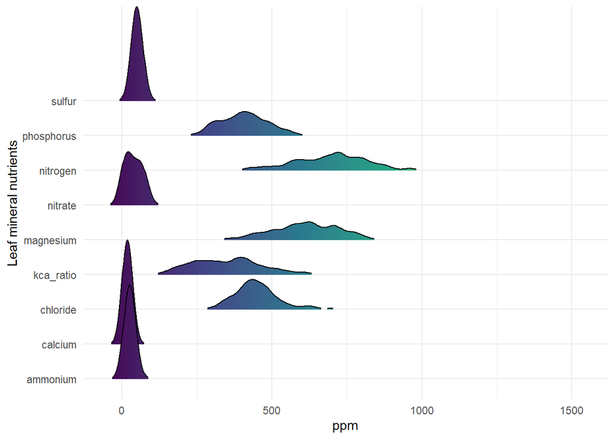

```r
library(ggridges)

sap_all_samples %>%
   #pivot longer so I can plot
   pivot_longer(where(is.numeric)) %>%
   mutate(across(c(name), as.factor)) %>%
   # plot this variables separately
   filter(!c(name %in% c("time_num", "n_conv_eff"))) %>%
   filter(c(name %in% c("nitrogen", "ammonium", "nitrate", "phosphorus", "calcium", "magnesium", "kca_ratio", "sulfur", "chloride"))) %>%
   #plot
   ggplot(., aes(x = value, y = name, fill = stat((x)))) +
   geom_density_ridges_gradient(scale = 3, rel_min_height = 0.01) + # for displaying a certain threshold
   labs(x = "ppm",
        y = "Leaf mineral nutrients") +
   scale_fill_viridis_c(option = "D") +
   theme_minimal() +
   theme(legend.position = "none")
```

Density plots of micronutrients and trace elements

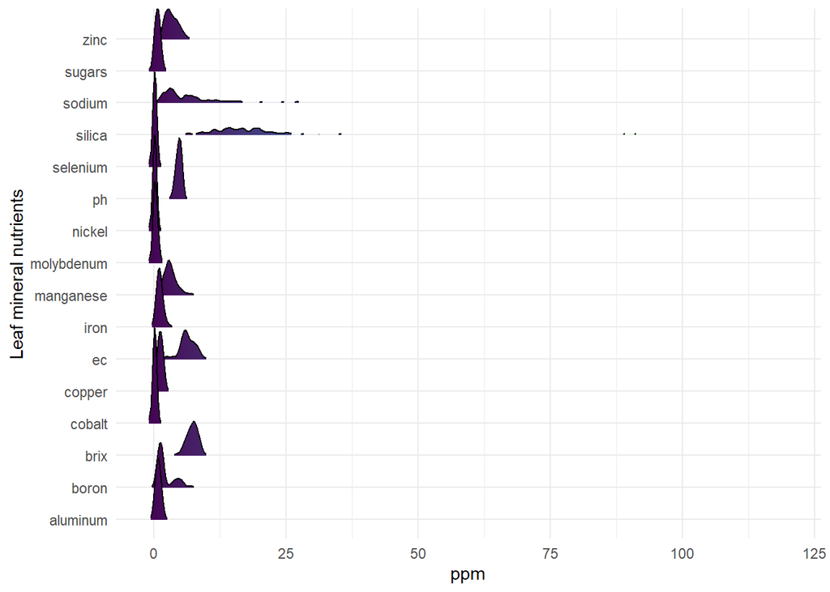

```r
library(ggridges)

sap_all_samples %>%
   #pivot longer so I can plot
   pivot_longer(where(is.numeric)) %>%
   mutate(across(c(name), as.factor)) %>%
   # plot this variables separately
   filter(!c(name %in% c("time_num", "n_conv_eff"))) %>%
   filter(!c(name %in% c("nitrogen", "ammonium", "nitrate", "phosphorus", "potassium", "calcium", "magnesium", "kca_ratio", "sulfur", "chloride"))) %>%
   #plot
   ggplot(., aes(x = value, y = name, fill = stat((x)))) +
   geom_density_ridges_gradient(scale = 3, rel_min_height = 0.01) + # for displaying a certain threshold
   labs(x = "ppm",
        y = "Leaf mineral nutrients") +
   scale_fill_viridis_c(option = "D") +
   theme_minimal() +
   theme(legend.position = "none")
```

Boxplots of Irrigation system within each block

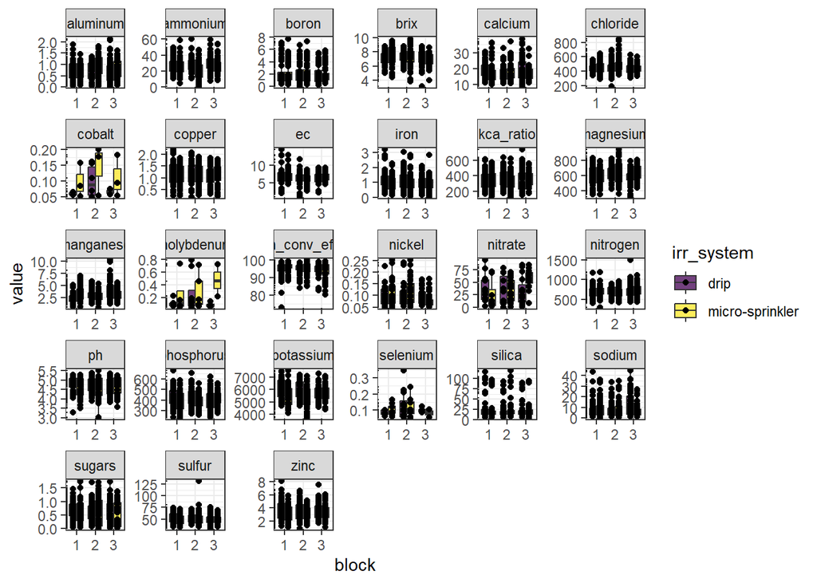

```r
sap_all_samples %>%
   #pivot longer so I can plot
   pivot_longer(where(is.numeric)) %>%
   mutate(across(c(name), as.factor)) %>%
   filter(!c(name %in% c("time_num"))) %>%
   #plot
   ggplot(aes(x= block, y = value, fill= irr_system)) +
   geom_boxplot(position = position_dodge(width = 0.75), alpha =0.75) +
   geom_point(position = position_dodge(width = 0.75)) +
   geom_rug() +
   facet_wrap(.~name, scales= "free") +
   scale_fill_viridis_d() +
   theme_bw()
```

Boxplots of foliar treatment within each irrigation system

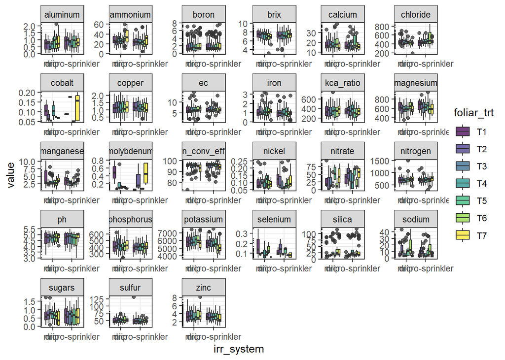

```r
sap_all_samples %>%
   #pivot longer so I can plot
   pivot_longer(where(is.numeric)) %>%
   mutate(across(c(name), as.factor)) %>%
   filter(!c(name %in% c("time_num"))) %>%
   #plot
   ggplot(aes(x= irr_system, y = value, fill= foliar_trt)) +
   geom_boxplot(position = position_dodge(width = 0.75), alpha =0.75) +
   #geom_point(position = position_dodge(width = 0.75)) +
   geom_rug() +
   facet_wrap(.~name, scales= "free") +
   scale_fill_viridis_d() +
   theme_bw()
```

Boxplots of new/old within foliar treatment

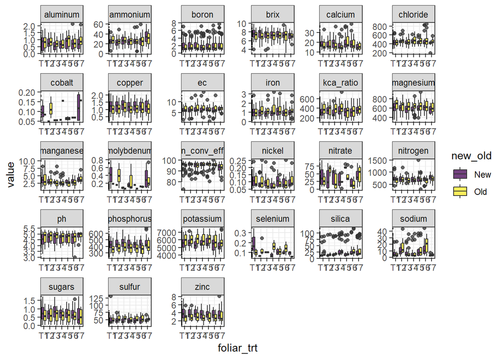

```r
sap_all_samples %>%
   #pivot longer so I can plot
   pivot_longer(where(is.numeric)) %>%
   mutate(across(c(name), as.factor)) %>%
   filter(!c(name %in% c("time_num"))) %>%
   #plot
   ggplot(aes(x= foliar_trt, y = value, fill= new_old)) +
   geom_boxplot(position = position_dodge(width = 0.75), alpha =0.75) +
   #geom_point(position = position_dodge(width = 0.75)) +
   geom_rug() +
   facet_wrap(.~name, scales= "free") +
   scale_fill_viridis_d() +
   theme_bw()
```

```r
sap_all_samples %>%
  head(15) %>%
  gt() %>%
  tab_style(style = cell_text(weight = "bold"), locations = cells_column_labels())
```

Firt 15 rows of 336 observations in the dataset. Excep Kca_ratio, ph, ec, brix, and sugars, all other variables are in ppm. NAN indicates that the values were <0.05 pmm.

| block | irr_system | foliar_trt | new_old | time_num | time | nitrogen | ammonium | nitrate | n_conv_eff | phosphorus | potassium | calcium | kca_ratio | magnesium | sulfur | iron | manganese | boron | copper | zinc | chloride | aluminum | sodium | silica | sugars | brix | ph | ec | cobalt | … |
| --- | --- | --- | --- | --- | --- | --- | --- | --- | --- | --- | --- | --- | --- | --- | --- | --- | --- | --- | --- | --- | --- | --- | --- | --- | --- | --- | --- | --- | --- | --- |
| 1 | drip | T1 | New | 40 | 40 | 427 | 21.0 | 94.0 | 73.1 | 543 | 5150 | 20.8 | 248 | 477 | 57.1 | 1.270 | 2.60 | 7.030 | 2.100 | 5.65 | 449 | 0.914 | 7.32 | 63.80 | 1.170 | 6.8 | 5.18 | 6.56 | NaN | … |
| 1 | drip | T1 | New | 72 | 72 | 591 | 22.3 | NaN | 96.2 | 450 | 6080 | 23.6 | 258 | 761 | 40.6 | 0.941 | 2.70 | 1.640 | 1.520 | 4.90 | 433 | 0.265 | 1.61 | 8.21 | 1.130 | 7.6 | 3.27 | 3.51 | NaN | … |
| 1 | drip | T1 | New | 86 | 86 | 1170 | 37.5 | 13.4 | 95.6 | 329 | 6230 | 12.1 | 515 | 723 | 34.3 | 0.328 | 1.30 | 0.734 | 0.484 | 2.25 | 433 | NaN | 2.97 | 12.80 | 0.409 | 8.4 | 4.77 | 7.96 | NaN | … |
| 1 | drip | T1 | New | 100 | 100 | 905 | 26.9 | NaN | 97.0 | 518 | 6380 | 19.3 | 331 | 729 | 57.2 | 1.320 | 2.38 | 1.460 | 1.010 | 2.58 | 500 | 1.090 | 10.70 | 25.10 | 0.472 | 8.4 | 4.32 | 5.75 | NaN | … |
| 1 | drip | T1 | Old | 40 | 40 | 403 | 33.2 | NaN | 91.8 | 407 | 5060 | 20.1 | 252 | 500 | 50.5 | 0.925 | 2.92 | 4.730 | 1.640 | 4.42 | 384 | 0.744 | 5.56 | 68.00 | 1.310 | 6.2 | 5.25 | 6.22 | NaN | … |
| 1 | drip | T1 | Old | 72 | 72 | 441 | 20.0 | 35.7 | 87.4 | 345 | 6110 | 18.8 | 325 | 758 | 45.2 | 0.988 | 1.83 | 1.210 | 1.010 | 2.92 | 409 | 0.541 | 1.14 | 13.40 | 0.572 | 6.8 | 5.01 | 2.17 | NaN | … |
| 1 | drip | T1 | Old | 86 | 86 | 703 | 40.2 | 17.8 | 91.7 | 306 | 6900 | 13.2 | 523 | 830 | 47.1 | 0.514 | 1.08 | 0.586 | 0.377 | 1.80 | 434 | NaN | 2.89 | 14.80 | 0.275 | 8.2 | 4.86 | 8.36 | NaN | … |
| 1 | drip | T1 | Old | 100 | 100 | 708 | 38.6 | NaN | 94.5 | 457 | 6880 | 16.6 | 414 | 647 | 59.6 | 1.830 | 1.58 | 1.240 | 0.811 | 1.92 | 447 | 1.250 | 4.44 | 16.20 | 0.335 | 7.8 | 4.43 | 5.71 | NaN | … |
| 1 | drip | T2 | New | 40 | 40 | 878 | 20.0 | NaN | 97.7 | 509 | 4890 | 22.1 | 221 | 428 | 62.8 | 0.759 | 2.51 | 4.460 | 1.710 | 4.79 | 395 | 0.772 | 21.50 | 9.32 | 0.818 | 5.8 | 5.17 | 5.65 | NaN | … |
| 1 | drip | T2 | New | 72 | 72 | 568 | 13.3 | NaN | 97.7 | 435 | 6180 | 22.3 | 277 | 654 | 42.2 | 1.070 | 2.93 | 1.290 | 1.310 | 4.91 | 424 | 0.255 | 5.24 | 6.66 | 0.910 | 6.8 | 4.97 | 5.14 | NaN | … |
| 1 | drip | T2 | New | 86 | 86 | 953 | 10.4 | NaN | 98.9 | 391 | 6690 | 16.1 | 416 | 722 | 45.0 | 0.257 | 2.03 | 0.586 | 0.625 | 3.04 | 500 | NaN | 7.81 | 11.00 | 0.431 | 8.8 | 4.82 | 7.88 | NaN | … |
| 1 | drip | T2 | New | 100 | 100 | 799 | 26.5 | NaN | 96.7 | 500 | 6040 | 15.7 | 385 | 506 | 48.0 | 1.240 | 1.88 | 1.040 | 0.891 | 2.09 | 478 | 0.756 | 10.20 | 13.30 | 0.521 | 8.0 | 4.14 | 5.39 | NaN | … |
| 1 | drip | T2 | Old | 40 | 40 | 588 | 23.6 | NaN | 96.0 | 424 | 5190 | 30.7 | 169 | 405 | 70.3 | 0.903 | 2.87 | 3.340 | 1.610 | 3.55 | 452 | 1.170 | 43.80 | 17.00 | 0.641 | 6.0 | 5.28 | 5.98 | NaN | … |
| 1 | drip | T2 | Old | 72 | 72 | 607 | 22.5 | NaN | 96.3 | 379 | 6450 | 26.9 | 240 | 705 | 49.3 | 1.870 | 2.55 | 1.360 | 1.220 | 3.74 | 493 | 0.624 | 7.98 | 11.80 | 1.090 | 6.4 | 4.16 | 2.27 | 0.064 | … |
| 1 | drip | T2 | Old | 86 | 86 | 710 | 21.4 | NaN | 97.0 | 280 | 6800 | 15.4 | 442 | 731 | 44.1 | 0.809 | 1.43 | 0.399 | 0.439 | 2.18 | 503 | 0.073 | 8.72 | 12.20 | 0.370 | 7.8 | 4.79 | 7.99 | NaN | … |

## 5.3 3) Statistical model fitting

Let’s remember that `lmer()` function does not allow to specify correlation structures while `lme()` allows to fit spatial and temporal correlation structures.

Because our data includes a time variable, it should be analyzed as a **split-split-plot repeated measures**.

- For fixed effects, let’s remember that our whole-plot is irrigation system, split-plot is foliar treatment, spli-split plot is new-old leaves, and time is our repeated measures.
- For random effects the nesting goes from biggest to lowest: replicate/whole-plot/split-plot/split-split-plot. Thus, time_num is considered to be nested within old_new leaves.

Define the correlation structures to be used in the model and select the response variables to use

```r
# Define a list of correlation structures
cor_structures <- list(
  none = NULL,
  CompSymm = corCompSymm(form = ~ time_num ),
  Symm = corSymm(),
  #ar1 = corAR1(form = ~ time_num ),
  Car1 = corCAR1(form = ~ time_num ),
  ARMA = corARMA(p = 1, q = 1),
  Exp = corExp(form = ~ time_num ),
  Gaus = corGaus(form = ~ time_num ),
  Lin = corLin(form = ~ time_num ),
  Ratio = corRatio(form = ~ time_num ),
  Spher = corSpher(form = ~ time_num )
)

response_vars <-
   sap_all_samples %>%
   select(!c(time_num, nitrate, cobalt, molybdenum, nickel, selenium)) %>%
  select(where(is.numeric)) %>%
  names()
```

Create a function to fit the model with a given correlation structure and response variable. The function will return the AIC of the fitted model.

```r
options(contrasts = c("contr.sum", "contr.poly"))

# Function to fit model
fit_model <- function(response, cor_struct) {
  formula <- as.formula(paste(response, "~ irr_system * foliar_trt * new_old * time"))

  tryCatch(
    lme(
      formula,
      random = ~1 | block/irr_system/foliar_trt/new_old,
      correlation = cor_struct,
      data = sap_all_samples,
      na.action = na.exclude,
      control = lmeControl(opt = "optim")
    ),
    error = function(e) NULL
  )
}

# Now map over correlation structures and response variables
results <- map(cor_structures, function(cor_struct) {
  map(response_vars, function(response) {
    model <- fit_model(response, cor_struct)
    if (!is.null(model)) {
      AIC(model)
    } else {
      NA_real_
    }
  }) %>% set_names(response_vars)
})
```

Create a table of AIC values for each response variable and correlation structure.

```r
# Make a tidy table
aic_table <- results %>%
  map_dfr(~ as_tibble(.x), .id = "cor_structure")

# View the AIC table
aic_table %>%
  gt() %>%
  fmt_number(columns = everything(), decimals = 2) %>%
  cols_label(
    cor_structure = "Correlation\nStructure",
    brix = "°Brix",
    n_conv_eff = "N Conv\nEff",
    nitrogen = "N",
    ammonium = md("NH<sub>4</sub>"),
    phosphorus = "P",
    potassium = "K",
    calcium = "Ca",
    magnesium     = "Mg",
    kca_ratio    = "K/Ca",
    sulfur = "S",
    iron = "Fe",
    manganese = "Mn",
    boron = "B",
    zinc = "Zn",
    copper = "Cu",
    sugars = "Sugars",
    ec = "EC",
    silica   = "Si",
    chloride = "Cl",
    sodium   = "Na",
    ph = "pH") %>%
  cols_move (columns = c(nitrogen, n_conv_eff, phosphorus, potassium, calcium, kca_ratio, magnesium, sulfur), after = ammonium) %>%
  cols_move (columns = c(iron, copper, zinc, manganese, chloride, silica, sodium), after = boron) %>%
  tab_style(style = cell_text(weight = "bold"),
             locations = cells_column_labels())
```

AIC values obtained from the linear mixed models fitted with different correlation structures for each of the response variables.

| Correlation Structure | NH<sub>4</sub> | N | N Conv Eff | P | K | Ca | K/Ca | Mg | S | B | Fe | Cu | Zn | Mn | Cl | Si | Na | aluminum | Sugars | °Brix | pH | EC |
| --- | --- | --- | --- | --- | --- | --- | --- | --- | --- | --- | --- | --- | --- | --- | --- | --- | --- | --- | --- | --- | --- | --- |
| none | 2,211.21 | 3,458.83 | 1,793.12 | 2,956.96 | 4,039.99 | 1,929.74 | 3,206.18 | 3,132.51 | 2,147.09 | 975.16 | 803.38 | 339.26 | 1,063.84 | 1,180.94 | 3,138.48 | 2,547.69 | 2,134.12 | NA | 589.46 | 1,054.54 | 696.19 | 1,489.88 |
| CompSymm | 2,212.32 | 3,457.72 | 1,783.93 | 2,956.61 | 4,035.53 | 1,929.30 | 3,208.18 | 3,134.51 | 2,148.31 | 971.40 | 805.38 | 341.26 | 1,062.10 | 1,182.94 | 3,140.46 | 2,488.43 | 2,100.09 | NA | 590.34 | 1,051.12 | 696.88 | 1,489.10 |
| Symm | 2,214.17 | 3,453.89 | 1,783.12 | 2,955.46 | 4,018.55 | 1,904.22 | 3,203.83 | 3,133.53 | 2,151.46 | 879.68 | 808.66 | 346.14 | 1,063.15 | 1,173.20 | 3,137.00 | NA | 1,998.37 | NA | 579.12 | 1,049.14 | 611.27 | 1,342.11 |
| Car1 | 2,213.21 | 3,460.82 | 1,795.12 | 2,958.95 | 4,041.99 | 1,931.73 | 3,208.18 | 3,134.51 | 2,149.09 | 977.15 | 805.38 | 341.26 | 1,065.83 | 1,182.94 | 3,140.48 | 2,549.69 | 2,136.11 | NA | 591.46 | 1,056.54 | 698.19 | 1,491.88 |
| ARMA | 2,214.74 | 3,458.59 | 1,796.34 | 2,954.97 | 4,043.99 | 1,931.27 | 3,208.76 | 3,134.61 | 2,150.61 | 975.50 | 805.60 | 341.05 | 1,063.39 | 1,174.04 | 3,138.76 | NA | 2,107.19 | NA | 587.26 | 1,053.58 | 698.95 | 1,489.88 |
| Exp | 2,213.20 | 3,460.82 | 1,795.12 | 2,958.91 | 4,040.40 | 1,931.73 | 3,208.18 | 3,128.62 | 2,149.09 | 943.71 | 805.38 | 339.55 | 1,065.83 | 1,180.98 | 3,138.59 | 2,512.84 | 2,136.11 | NA | 591.46 | 1,052.83 | 698.19 | 1,491.90 |
| Gaus | 2,213.20 | 3,460.82 | 1,795.12 | 2,958.96 | NA | 1,931.73 | 3,208.19 | 3,128.43 | 2,149.09 | 932.89 | 805.38 | 341.26 | 1,065.83 | 1,181.69 | 3,138.87 | 2,453.78 | 2,136.11 | NA | 591.46 | 1,049.73 | 698.19 | 1,491.89 |
| Lin | 2,212.91 | 3,460.83 | 1,795.09 | 2,958.84 | 4,040.45 | 1,931.74 | 3,208.15 | 3,128.48 | 2,149.09 | 934.61 | 804.84 | 340.22 | 1,065.83 | 1,181.69 | 3,138.86 | 2,481.69 | 2,136.11 | NA | 587.44 | 1,049.57 | 698.19 | 1,491.89 |
| Ratio | 2,213.29 | 3,460.82 | 1,795.12 | 2,958.97 | 4,041.99 | 1,931.74 | 3,229.17 | 3,128.95 | 2,149.09 | 933.17 | 805.85 | 339.49 | 1,065.83 | 1,180.75 | 3,138.55 | 2,465.26 | 2,136.11 | NA | 591.46 | 1,054.18 | 698.19 | 1,491.90 |
| Spher | 2,212.92 | 3,460.82 | 1,795.09 | 2,958.85 | 4,040.45 | 1,931.74 | 3,208.14 | 3,128.45 | 2,149.09 | 939.37 | 804.83 | 340.22 | 1,065.83 | 1,181.70 | 3,138.87 | 2,507.49 | 2,136.11 | NA | 587.43 | 1,049.57 | 698.19 | 1,491.88 |

Select the best model for each response variable based on AIC values.

```r
best_model_table <-
   aic_table %>%
  pivot_longer(
    cols = -cor_structure,
    names_to = "response",
    values_to = "AIC"
  ) %>%
  group_by(response) %>%
  slice_min(AIC, with_ties = FALSE) %>%
  ungroup() %>%
  select(response, cor_structure, AIC)

best_model_table %>%
mutate(response = case_when(
    response == "brix"~ "°Brix",
    response == "n_conv_eff" ~ "N Conv\nEff",
    response == "nitrogen" ~ "N",
    response == "ammonium" ~ "NH4",
    response == "phosphorus" ~ "P",
    response == "potassium" ~ "K",
    response == "calcium" ~ "Ca",
    response == "magnesium"  ~ "Mg",
    response == "kca_ratio"  ~ "K/Ca",
    response == "sulfur" ~ "S",
    response == "iron" ~ "Fe",
    response == "manganese" ~ "Mn",
    response == "boron" ~ "B",
    response == "zinc" ~ "Zn",
    response == "copper" ~ "Cu",
    response == "sugars" ~ "Sugars",
    response == "ec" ~ "EC",
    response == "silica"  ~ "Si",
    response == "chloride" ~ "Cl",
    response == "sodium"  ~ "Na",
    response == "ph" ~ "pH",
    TRUE ~ response)) %>%
  gt() %>%
  fmt_number(columns = everything(), decimals = 1) %>%
  cols_label(
    response = "Response \n variable",
    cor_structure = "Correlation\nStructure") %>%
  tab_style(style = cell_text(weight = "bold"),
             locations = cells_column_labels())
```

Best correlation structure based on the lowest Aic for each of the response variables.

| Response variable | Correlation Structure | AIC |
| --- | --- | --- |
| aluminum | none | NA |
| NH4 | none | 2,211.2 |
| B | Symm | 879.7 |
| °Brix | Symm | 1,049.1 |
| Ca | Symm | 1,904.2 |
| Cl | Symm | 3,137.0 |
| Cu | none | 339.3 |
| EC | Symm | 1,342.1 |
| Fe | none | 803.4 |
| K/Ca | Symm | 3,203.8 |
| Mg | Gaus | 3,128.4 |
| Mn | Symm | 1,173.2 |
| N Conv Eff | Symm | 1,783.1 |
| N | Symm | 3,453.9 |
| pH | Symm | 611.3 |
| P | ARMA | 2,955.0 |
| K | Symm | 4,018.6 |
| Si | Gaus | 2,453.8 |
| Na | Symm | 1,998.4 |
| Sugars | Symm | 579.1 |
| S | none | 2,147.1 |
| Zn | CompSymm | 1,062.1 |

Based on the best correlation structure for each response variable, fit the final models.

```r
# Make it easier to access
best_model_list <- best_model_table %>% deframe() # named vector: response -> cor_structure

# Now fit the models
best_models <- map2(
  names(best_model_list),    # responses
  best_model_list,           # best correlation structure names
  ~ {
    formula <- as.formula(paste(.x, "~ irr_system * foliar_trt * new_old * time"))
    cor_struct <- cor_structures[[.y]]  # get the correct correlation object

    tryCatch(
      lme(
        formula,
        random = ~ 1 | block/irr_system/foliar_trt/new_old,
        correlation = cor_struct,
        data = sap_all_samples,
        na.action = na.exclude,
        control = lmeControl(opt = "optim")
      ),
      error = function(e) NULL
    )
  }
)

# Name the list by response
names(best_models) <- names(best_model_list)
```

### 5.3.1 a) Table of p-values

```r
# Create a table of p-values
pval_table <-
  best_models %>%
   discard(is.null) %>%  # <-- remove NULL models first
  map(~ .x %>% Anova(type = 3) %>% tidy()) %>% # get Anova output and tidy
  map(~ .x %>% clean_names() %>% select(term, p_value)) %>% # clean names
  bind_rows(.id = "response") %>% # make a big table
  pivot_wider(names_from = response, values_from = p_value) %>% # reshape
  filter(term != "(Intercept)")  # remove intercept



# Start with basic table
tbl <- pval_table %>%
  gt() %>%
  cols_label(term = "Factor") %>%
  fmt_number(columns = everything(), decimals = 3) %>%
  tab_header(title = "", subtitle = " ") %>%
  tab_options(heading.align = "left",
              table_body.hlines.width = px(0)) %>%
  cols_label(
    brix = "°Brix",
    n_conv_eff = "N Conv\nEff",
    nitrogen = "N",
    ammonium = md("NH<sub>4</sub>"),
    phosphorus = "P",
    potassium = "K",
    calcium = "Ca",
    magnesium     = "Mg",
    kca_ratio    = "K/Ca",
    sulfur = "S",
    iron = "Fe",
    manganese = "Mn",
    boron = "B",
    zinc = "Zn",
    copper = "Cu",
    sugars = "Sugars",
    ec = "EC",
    silica   = "Si",
    chloride = "Cl",
    sodium   = "Na",
    ph = "pH") %>%
  cols_move (columns = c(nitrogen, n_conv_eff, phosphorus, potassium, calcium, kca_ratio, magnesium, sulfur), after = ammonium) %>%
  cols_move (columns = c(iron, copper, zinc, manganese, chloride, silica, sodium), after = boron) %>%
  tab_style(style = cell_text(weight = "bold"),
             locations = cells_column_labels()) %>%
  tab_style(style = cell_fill(color = "lightgray"),
            locations = cells_body(rows = seq(1, nrow(pval_table), 2))) %>%
  tab_source_note("P ≤ 0.05 indicates significance. Significant values are in bold.")

# highlight in bold the significant p-values (p ≤ 0.05) in the table.
tbl <- reduce(
  names(pval_table)[-1],  # all p-value columns (skip 'term')
  .init = tbl,
  .f = ~ tab_style(
    .x,
    style = cell_text(weight = "bold"),
    locations = cells_body(columns = .y, rows = .data[[.y]] < 0.05)
  )
)

tbl
```

p-values of leaf sap analysis

| Factor | NH<sub>4</sub> | N | N Conv Eff | P | K | Ca | K/Ca | Mg | S | B | Fe | Cu | Zn | Mn | Cl | Si | Na | °Brix | EC | pH | Sugars |
| --- | --- | --- | --- | --- | --- | --- | --- | --- | --- | --- | --- | --- | --- | --- | --- | --- | --- | --- | --- | --- | --- |
| irr_system | 0.025 | 0.872 | 0.794 | 0.030 | 0.000 | 0.161 | 0.470 | 0.109 | 0.021 | 0.959 | 0.002 | 0.935 | 0.000 | 0.805 | 0.229 | 0.895 | 0.718 | 0.917 | 0.843 | 0.478 | 0.227 |
| foliar_trt | 0.003 | 0.307 | 0.114 | 0.012 | 0.043 | 0.017 | 0.284 | 0.726 | 0.393 | 0.866 | 0.477 | 0.014 | 0.613 | 0.127 | 0.788 | 0.098 | 0.000 | 0.886 | 0.960 | 0.299 | 0.180 |
| new_old | 0.808 | 0.000 | 0.626 | 0.000 | 0.000 | 0.211 | 0.000 | 0.000 | 0.000 | 0.000 | 0.000 | 0.000 | 0.000 | 0.087 | 0.011 | 0.165 | 0.019 | 0.000 | 0.220 | 0.027 | 0.000 |
| time | 0.000 | 0.000 | 0.000 | 0.000 | 0.000 | 0.000 | 0.000 | 0.000 | 0.000 | 0.000 | 0.000 | 0.000 | 0.000 | 0.000 | 0.000 | 0.000 | 0.000 | 0.000 | 0.000 | 0.000 | 0.000 |
| irr_system:foliar_trt | 0.080 | 0.883 | 0.581 | 0.245 | 0.005 | 0.899 | 0.831 | 0.236 | 0.427 | 0.993 | 0.681 | 0.542 | 0.009 | 0.658 | 0.301 | 0.969 | 0.992 | 0.131 | 0.995 | 0.816 | 0.000 |
| irr_system:new_old | 0.157 | 0.014 | 0.681 | 0.326 | 0.483 | 0.286 | 0.161 | 0.009 | 0.217 | 0.902 | 0.029 | 0.235 | 0.000 | 0.425 | 0.643 | 0.938 | 0.782 | 0.023 | 0.576 | 0.602 | 0.009 |
| foliar_trt:new_old | 0.213 | 0.732 | 0.987 | 0.978 | 0.012 | 0.402 | 0.109 | 0.626 | 0.084 | 0.977 | 0.090 | 0.727 | 0.450 | 0.544 | 0.384 | 1.000 | 0.010 | 0.323 | 0.983 | 0.830 | 0.193 |
| irr_system:time | 0.246 | 0.489 | 0.000 | 0.000 | 0.032 | 0.009 | 0.003 | 0.001 | 0.000 | 0.007 | 0.062 | 0.000 | 0.014 | 0.007 | 0.000 | 0.792 | 0.000 | 0.000 | 0.002 | 0.000 | 0.000 |
| foliar_trt:time | 0.000 | 0.006 | 0.081 | 0.000 | 0.000 | 0.000 | 0.000 | 0.000 | 0.000 | 0.004 | 0.014 | 0.020 | 0.006 | 0.049 | 0.298 | 0.000 | 0.000 | 0.205 | 0.000 | 0.000 | 0.018 |
| new_old:time | 0.283 | 0.880 | 0.638 | 0.034 | 0.163 | 0.809 | 0.302 | 0.000 | 0.000 | 0.000 | 0.000 | 0.000 | 0.000 | 0.000 | 0.037 | 0.835 | 0.004 | 0.780 | 0.000 | 0.015 | 0.000 |
| irr_system:foliar_trt:new_old | 0.831 | 0.425 | 0.730 | 0.343 | 0.462 | 0.994 | 0.963 | 0.376 | 0.940 | 0.997 | 0.837 | 0.575 | 0.140 | 0.408 | 0.926 | 1.000 | 0.999 | 0.834 | 0.983 | 0.957 | 0.093 |
| irr_system:foliar_trt:time | 0.583 | 0.222 | 0.640 | 0.998 | 0.838 | 0.714 | 0.347 | 0.002 | 0.061 | 0.000 | 0.050 | 0.010 | 0.712 | 0.049 | 0.539 | 0.077 | 0.000 | 0.651 | 0.707 | 0.353 | 0.982 |
| irr_system:new_old:time | 0.317 | 0.332 | 0.810 | 0.931 | 0.050 | 0.337 | 0.047 | 0.000 | 0.390 | 0.994 | 0.034 | 0.767 | 0.371 | 0.035 | 0.486 | 0.968 | 0.955 | 0.624 | 0.182 | 0.335 | 0.010 |
| foliar_trt:new_old:time | 0.666 | 0.994 | 0.947 | 0.725 | 0.950 | 0.864 | 0.959 | 0.237 | 0.190 | 0.994 | 0.689 | 0.833 | 0.547 | 0.973 | 0.721 | 1.000 | 0.003 | 0.927 | 0.121 | 0.807 | 0.041 |
| irr_system:foliar_trt:new_old:time | 0.896 | 0.829 | 0.816 | 0.954 | 0.926 | 0.928 | 0.954 | 0.985 | 0.973 | 0.389 | 0.829 | 0.942 | 0.888 | 0.869 | 0.679 | 1.000 | 1.000 | 0.489 | 0.483 | 0.984 | 0.874 |

P ≤ 0.05 indicates significance. Significant values are in bold.

### 5.3.2 a) model assumptions

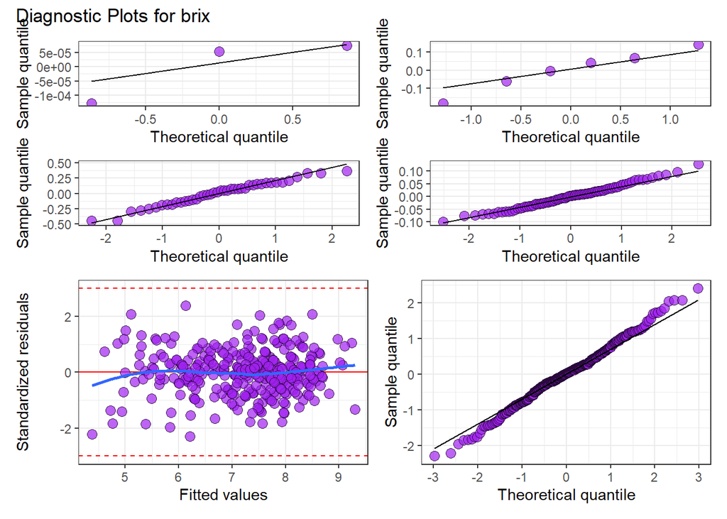

```r
library(broom.mixed)  # for augment()

# Discard NULL models from best_models
best_models_clean <- best_models %>% discard(is.null)


# 1. Make residuals and standardized residuals for each model
residuals_df <-
  best_models %>%
  discard(is.null) %>%
  map(~ augment(.x) %>%
        mutate(.stdresid = resid(.x, type = "pearson", scaled = TRUE))
      )

# 2. Plot random effects QQ-plots for each random term

plot_random_effects <- function(model) {
  raneffects <- ranef(model)

  map(raneffects, ~
    ggplot(.x, aes(sample = `(Intercept)`)) +
      stat_qq(shape = 21, fill = "purple", size = 3, alpha = 0.7) +
      stat_qq_line() +
      labs(x = "Theoretical quantile", y = "Sample quantile") +
      theme_bw()
  )
}

# 3. Plot residuals (fitted vs residuals) and QQ plot for residuals
plot_residuals <- function(resid_df) {
  fitted_vs_resid <-
    ggplot(resid_df, aes(.fitted, .stdresid)) +
      geom_hline(yintercept = 0, color = "red") +
      geom_point(shape = 21, fill = "purple", size = 3, alpha = 0.7) +
      geom_smooth(se = FALSE) +
      geom_hline(yintercept = c(-3, 3), linetype = "dashed", color = "red") +
      theme_bw() +
      labs(x = "Fitted values", y = "Standardized residuals")

  resid_qq <-
    ggplot(resid_df, aes(sample = .stdresid)) +
      stat_qq(shape = 21, fill = "purple", size = 3, alpha = 0.7) +
      stat_qq_line() +
      theme_bw() +
      labs(x = "Theoretical quantile", y = "Sample quantile")

  list(fitted_vs_resid = fitted_vs_resid, resid_qq = resid_qq)
}


# 4. map over everything
diagnostic_plots <- map2(
  names(best_models_clean),  # use the response names directly
  residuals_df,
  ~ {
    response_name <- .x  # .x is the name (e.g., "potassium")
    model <- best_models_clean[[response_name]]

    randef_plots <- plot_random_effects(model)
    resid_plots <- plot_residuals(.y)

    # combine the 6 plots
    full_plot <- (randef_plots[[1]] + randef_plots[[2]] + randef_plots[[3]] + randef_plots[[4]]) /
                 (resid_plots$fitted_vs_resid + resid_plots$resid_qq)

    # add a big title using patchwork
    full_plot + plot_annotation(title = paste("Diagnostic Plots for", response_name))
  }
)

# assign plot names
names(diagnostic_plots) <- names(best_models_clean)

diagnostic_plots$brix
```

### 5.3.3 b) post hoc tests

We are interested in those interactions with foliar treatment and time, so we will run post hoc tests on those models. First, we will start from higher order interactions.

#### 5.3.3.1 Foliar treatment, new/old, and time

Sodium

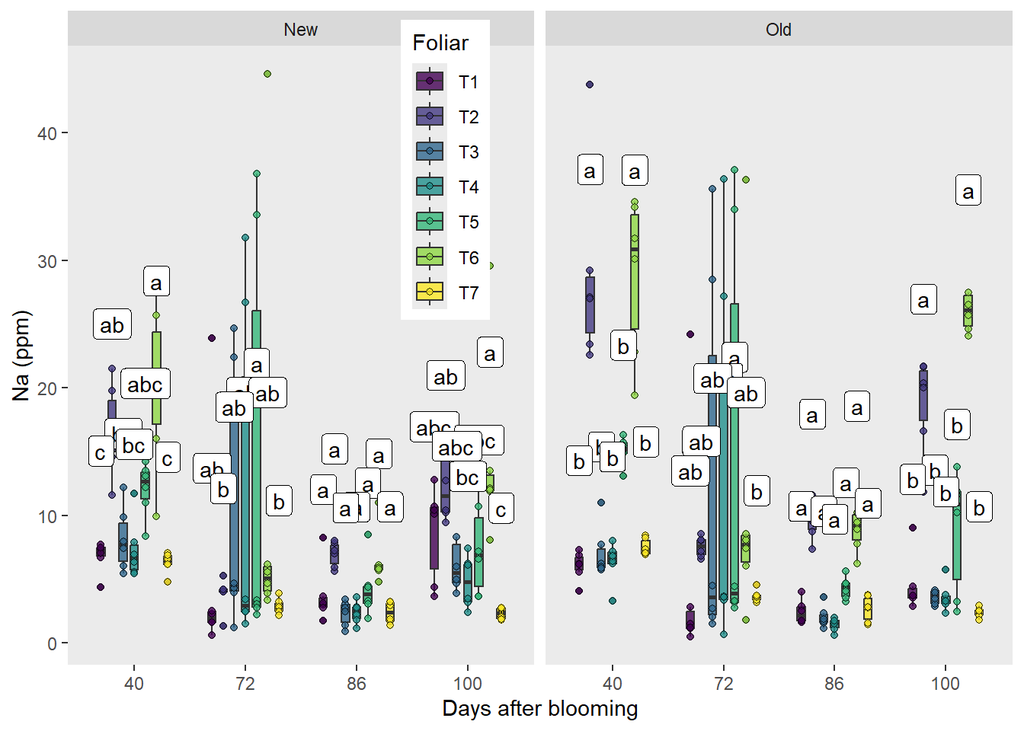

```r
na <-
   best_models$sodium %>%
   #estimated marginal means (a.k.a. least-squares means)
   emmeans(~  foliar_trt | new_old | time) %>% # compares foliar_trt within new_old at each time point (too much time to run interaction too)
   cld(alpha = 0.05, reversed = TRUE, adjust = "none", Letters=letters) %>%
   as.data.frame() %>%
   mutate(letter = trimws(.group))

ggplot(mapping = aes(fill = time)) +
   #raw data and boxplots
   geom_boxplot(data = sap_all_samples,
                aes(x = time, y = sodium, fill = foliar_trt),
                width = 0.5,
                alpha = 0.8,
                position = position_dodge(width = 0.7)) +
   geom_point(data = sap_all_samples,
               aes(x = time, y = sodium, fill = foliar_trt, group = foliar_trt),
               shape = 21,
               #size =3,
              position = position_dodge(width = 0.7),
               alpha = 0.8) +
   #adding letters
   geom_label(data = na,
              aes(x = time, y = emmean, label = letter, group = foliar_trt),
              fill = "white",
              position = position_dodge(width = 0.7),
               vjust = -3) +
   labs(x = "Days after blooming",
        y = "Na (ppm)",
        fill = "Foliar") +
   scale_fill_viridis_d() +
   facet_grid(.~new_old) +
   theme(panel.grid.major = element_blank(),
         panel.grid.minor = element_blank(),
         legend.position = c(0.4,0.8))
```

Nanocellulose may be causeing sodim increase because there are higher values for T2.

Sugars

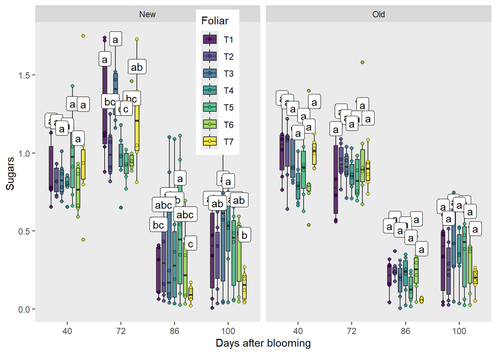

```r
sug <-
   best_models$sugars %>%
   #estimated marginal means (a.k.a. least-squares means)
   emmeans(~  foliar_trt | new_old | time) %>% # compares foliar_trt within new_old at each time point
   cld(alpha = 0.05, reversed = TRUE, adjust = "none", Letters=letters) %>%
   as.data.frame() %>%
   mutate(letter = trimws(.group))

ggplot(mapping = aes(fill = time)) +
   #raw data and boxplots
   geom_boxplot(data = sap_all_samples,
                aes(x = time, y = sugars, fill = foliar_trt),
                width = 0.5,
                alpha = 0.8,
                position = position_dodge(width = 0.7)) +
   geom_point(data = sap_all_samples,
               aes(x = time, y = sugars, fill = foliar_trt, group = foliar_trt),
               shape = 21,
               #size =3,
              position = position_dodge(width = 0.7),
               alpha = 0.8) +
   #adding letters
   geom_label(data = sug,
              aes(x = time, y = emmean, label = letter, group = foliar_trt),
              fill = "white",
              position = position_dodge(width = 0.7),
               vjust = -3) +
   labs(x = "Days after blooming",
        y = "Sugars ",
        fill = "Foliar") +
   scale_fill_viridis_d() +
   facet_grid(.~new_old) +
   theme(panel.grid.major = element_blank(),
         panel.grid.minor = element_blank(),
         legend.position = c(0.4,0.8))
```

#### 5.3.3.2 Irrigation system, foliar treatment, and time

Boron

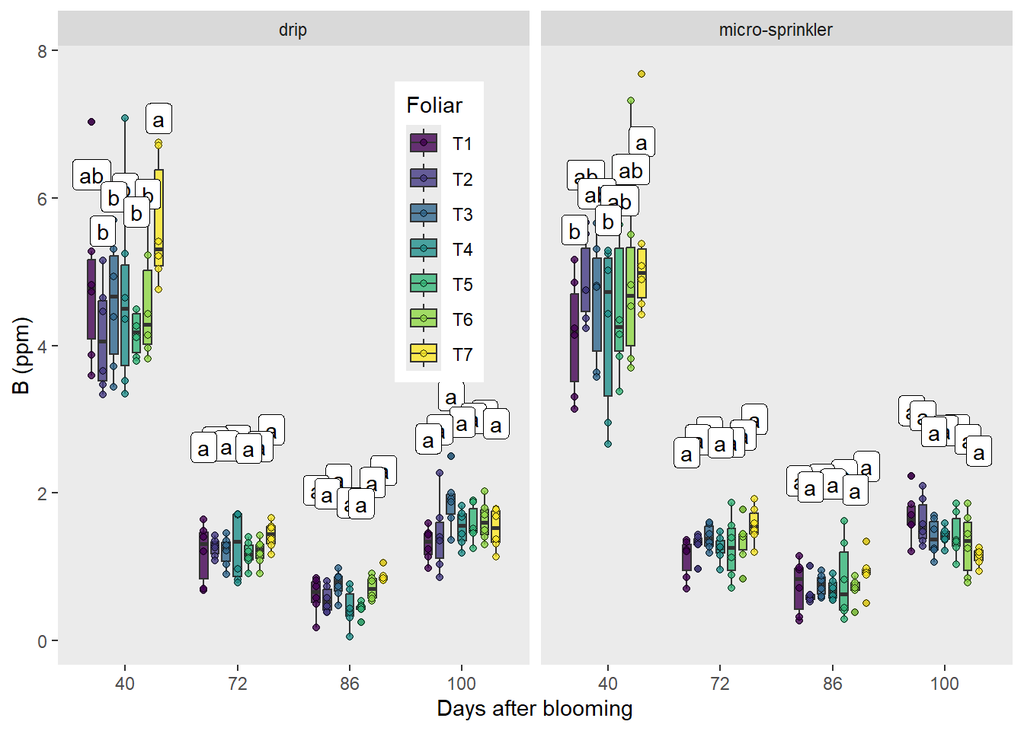

```r
#estimated marginal means (a.k.a. least-squares means)
b_sym_cld <-
   best_models$boron %>%
   emmeans(~  foliar_trt | irr_system | time) %>% # tests
   cld(alpha = 0.05, reversed = TRUE, adjust = "none", Letters=letters) %>%
   as.data.frame() %>%
   mutate(letter = trimws(.group))

ggplot(mapping = aes(fill = time)) +
   #raw data and boxplots
   geom_boxplot(data = sap_all_samples,
                aes(x = time, y = boron, fill = foliar_trt),
                width = 0.5,
                alpha = 0.8,
                position = position_dodge(width = 0.7)) +
   geom_point(data = sap_all_samples,
               aes(x = time, y = boron, fill = foliar_trt, group = foliar_trt),
               shape = 21,
               #size =3,
              position = position_dodge(width = 0.7),
               alpha = 0.8) +
   #adding letters
   geom_label(data = b_sym_cld,
              aes(x = time, y = emmean, label = letter, group = foliar_trt),
              fill = "white",
              position = position_dodge(width = 0.7),
               vjust = -3) +
   labs(x = "Days after blooming",
        y = "B (ppm)",
        fill = "Foliar") +
   scale_fill_viridis_d() +
   facet_grid(.~irr_system) +
   theme(panel.grid.major = element_blank(),
         panel.grid.minor = element_blank(),
         legend.position = c(0.4,0.7))
```

Copper

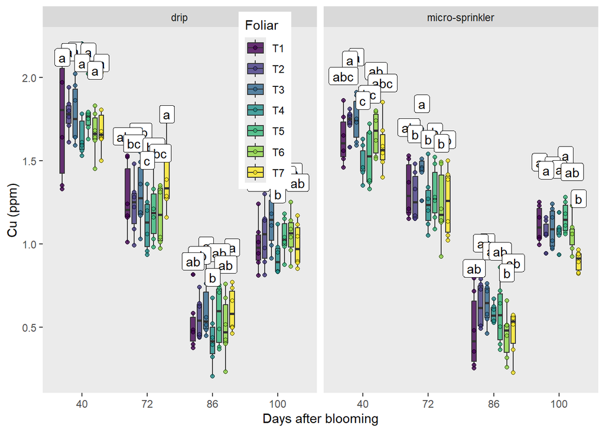

```r
#estimated marginal means (a.k.a. least-squares means)
cu <-
   best_models$copper %>%
   emmeans(~  foliar_trt | irr_system | time) %>% # compares new_old at each time point
   cld(alpha = 0.05, reversed = TRUE, adjust = "none", Letters=letters) %>%
   as.data.frame() %>%
   mutate(letter = trimws(.group))

ggplot(mapping = aes(fill = time)) +
   #raw data and boxplots
   geom_boxplot(data = sap_all_samples,
                aes(x = time, y = copper, fill = foliar_trt),
                width = 0.5,
                alpha = 0.8,
                position = position_dodge(width = 0.7)) +
   geom_point(data = sap_all_samples,
               aes(x = time, y = copper, fill = foliar_trt, group = foliar_trt),
               shape = 21,
               #size =3,
              position = position_dodge(width = 0.7),
               alpha = 0.8) +
   #adding letters
   geom_label(data = cu,
              aes(x = time, y = emmean, label = letter, group = foliar_trt),
              fill = "white",
              position = position_dodge(width = 0.7),
               vjust = -3) +
   labs(x = "Days after blooming",
        y = "Cu (ppm)",
        fill = "Foliar") +
   scale_fill_viridis_d() +
   facet_grid(.~irr_system) +
   theme(panel.grid.major = element_blank(),
         panel.grid.minor = element_blank(),
         legend.position = c(0.4,0.8))
```

Magnesium

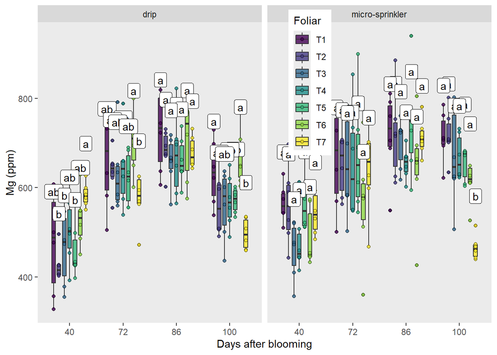

```r
mg <-
   best_models$magnesium %>%
   emmeans(~  foliar_trt |irr_system | time) %>% # compares foliar_trt within irrigation at each time point
   cld(alpha = 0.05, reversed = TRUE, adjust = "none", Letters=letters) %>%
   as.data.frame() %>%
   mutate(letter = trimws(.group))

ggplot(mapping = aes(fill = time)) +
   #raw data and boxplots
   geom_boxplot(data = sap_all_samples,
                aes(x = time, y = magnesium, fill = foliar_trt),
                width = 0.5,
                alpha = 0.8,
                position = position_dodge(width = 0.7)) +
   geom_point(data = sap_all_samples,
               aes(x = time, y = magnesium, fill = foliar_trt, group = foliar_trt),
               shape = 21,
               #size =3,
              position = position_dodge(width = 0.7),
               alpha = 0.8) +
   #adding letters
   geom_label(data = mg,
              aes(x = time, y = emmean, label = letter, group = foliar_trt),
              fill = "white",
              position = position_dodge(width = 0.7),
               vjust = -3) +
   labs(x = "Days after blooming",
        y = "Mg (ppm)",
        fill = "Foliar") +
   scale_fill_viridis_d() +
   facet_grid(.~irr_system) +
   theme(panel.grid.major = element_blank(),
         panel.grid.minor = element_blank(),
         legend.position = c(0.6,0.8))
```

Mainly differences in the drip irrigation.

Manganese

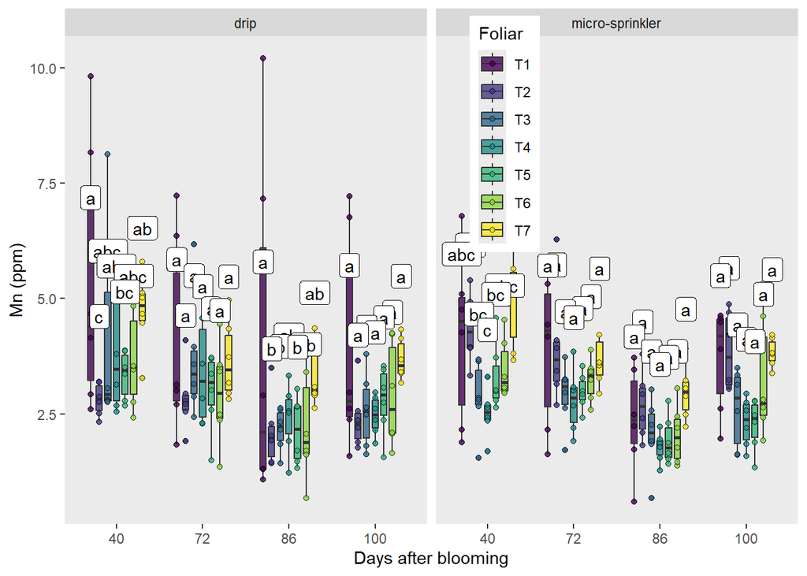

```r
mn <-
   best_models$manganese %>%
   emmeans(~  foliar_trt |irr_system | time) %>% # compares foliar_trt within irrigation at each time point
   cld(alpha = 0.05, reversed = TRUE, adjust = "none", Letters=letters) %>%
   as.data.frame() %>%
   mutate(letter = trimws(.group))

ggplot(mapping = aes(fill = time)) +
   #raw data and boxplots
   geom_boxplot(data = sap_all_samples,
                aes(x = time, y = manganese, fill = foliar_trt),
                width = 0.5,
                alpha = 0.8,
                position = position_dodge(width = 0.7)) +
   geom_point(data = sap_all_samples,
               aes(x = time, y = manganese, fill = foliar_trt, group = foliar_trt),
               shape = 21,
               #size =3,
              position = position_dodge(width = 0.7),
               alpha = 0.8) +
   #adding letters
   geom_label(data = mn,
              aes(x = time, y = emmean, label = letter, group = foliar_trt),
              fill = "white",
              position = position_dodge(width = 0.7),
               vjust = -3) +
   labs(x = "Days after blooming",
        y = "Mn (ppm)",
        fill = "Foliar") +
   scale_fill_viridis_d() +
   facet_grid(.~irr_system) +
   theme(panel.grid.major = element_blank(),
         panel.grid.minor = element_blank(),
         legend.position = c(0.6,0.8))
```

Seems like most of the foliar sprays were lower in Mn compared to control and T7 (soil fertilization), at least at 86 DAB in the drip irrigation.

#### 5.3.3.3 Foliar treatment and time

Ammonium

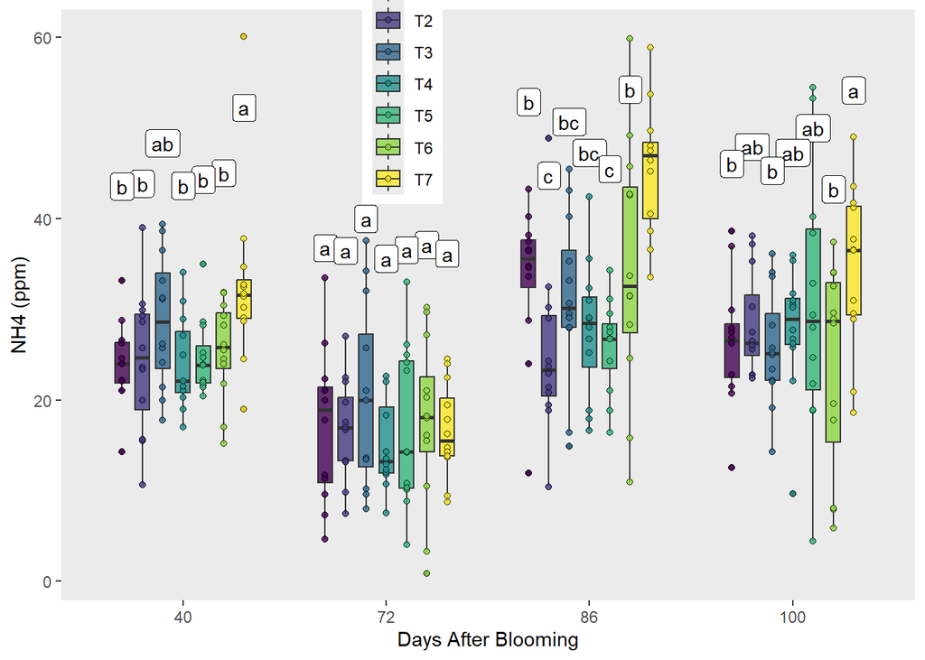

```r
#estimated marginal means (a.k.a. least-squares means)
nh4 <-
   best_models$ammonium  %>%
   emmeans(~  foliar_trt | time ) %>% # compares foliar_trt at each time point
   cld(alpha = 0.05, reversed = TRUE, adjust = "none", Letters=letters) %>%
   as.data.frame() %>%
   mutate(letter = trimws(.group))

ggplot(mapping = aes(fill = time)) +
   #raw data and boxplots
   geom_boxplot(data = sap_all_samples,
                aes(x = time, y = ammonium, fill = foliar_trt),
                width = 0.5,
                alpha = 0.8,
                position = position_dodge(width = 0.7)) +
   geom_point(data = sap_all_samples,
               aes(x = time, y = ammonium, fill = foliar_trt, group = foliar_trt),
               shape = 21,
               #size =3,
               alpha = 0.8, ,
              position = position_dodge(width = 0.7)) +
   #adding letters
   geom_label(data = nh4,
              aes(x = time, y = emmean, label = letter, group = foliar_trt),
              fill = "white",
              position = position_dodge(width = 0.7),
               vjust = -6) +
   labs(x = "Days After Blooming",
        y = "NH4 (ppm)",
        fill = "Foliar") +
   scale_fill_viridis_d() +
   #facet_grid(.~irr_system) +
   theme(panel.grid.major = element_blank(),
         panel.grid.minor = element_blank(),
         legend.position = c(0.4,0.9))
```

Calcium

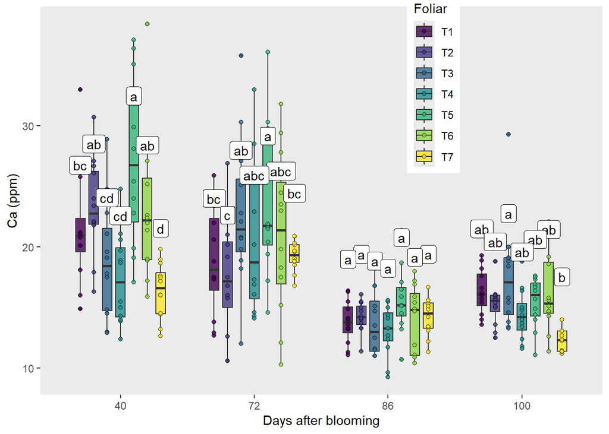

```r
#estimated marginal means (a.k.a. least-squares means)
ca <-
   best_models$calcium %>%
   emmeans(~  foliar_trt | time) %>% # compares foliar_trt at each time point
   cld(alpha = 0.05, reversed = TRUE, adjust = "none", Letters=letters) %>%
   as.data.frame() %>%
   mutate(letter = trimws(.group))

ggplot(mapping = aes(fill = time)) +
   #raw data and boxplots
   geom_boxplot(data = sap_all_samples,
                aes(x = time, y = calcium, fill = foliar_trt),
                width = 0.5,
                alpha = 0.8,
                position = position_dodge(width = 0.7)) +
   geom_point(data = sap_all_samples,
               aes(x = time, y = calcium, fill = foliar_trt, group = foliar_trt),
               shape = 21,
               #size =3,
              position = position_dodge(width = 0.7),
               alpha = 0.8) +
   #adding letters
   geom_label(data = ca,
              aes(x = time, y = emmean, label = letter, group = foliar_trt),
              fill = "white",
              position = position_dodge(width = 0.7),
               vjust = -3) +
   labs(x = "Days after blooming",
        y = "Ca (ppm)",
        fill = "Foliar") +
   scale_fill_viridis_d() +
   #facet_grid(.~irr_system) +
   theme(panel.grid.major = element_blank(),
         panel.grid.minor = element_blank(),
         legend.position = c(0.7,0.8))
```

Electrical conductivity

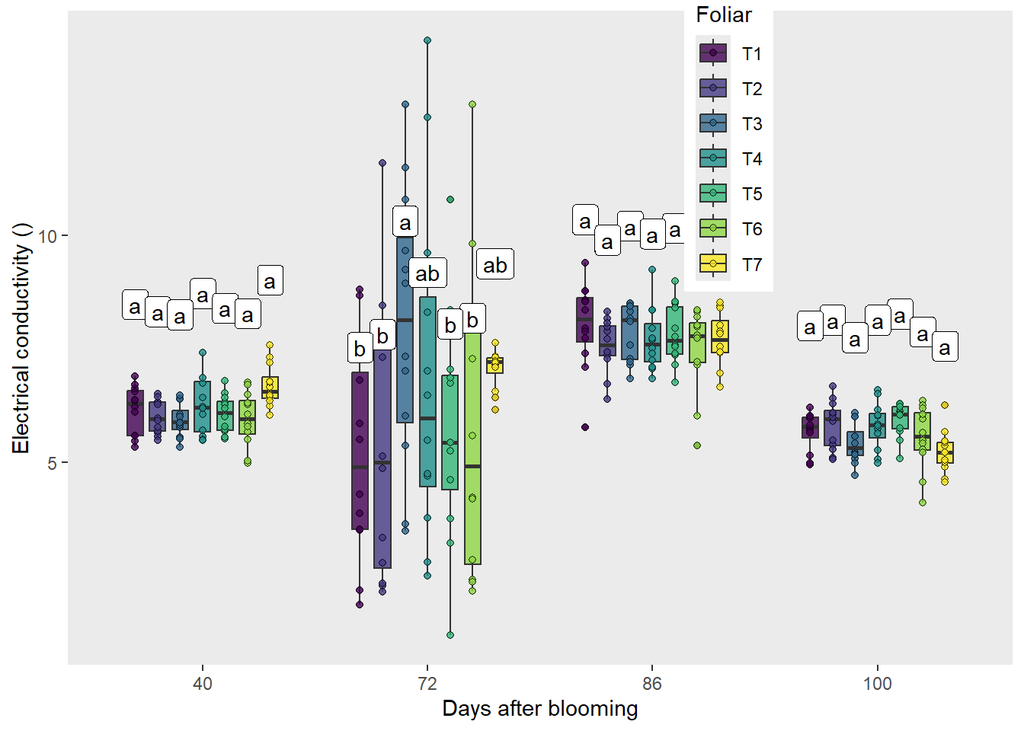

```r
ec <-
   best_models$ec %>%
   emmeans(~  foliar_trt | time) %>% # compares foliar_trt at each time point
   cld(alpha = 0.05, reversed = TRUE, adjust = "none", Letters=letters) %>%
   as.data.frame() %>%
   mutate(letter = trimws(.group))

ggplot(mapping = aes(fill = time)) +
   #raw data and boxplots
   geom_boxplot(data = sap_all_samples,
                aes(x = time, y = ec, fill = foliar_trt),
                width = 0.5,
                alpha = 0.8,
                position = position_dodge(width = 0.7)) +
   geom_point(data = sap_all_samples,
               aes(x = time, y = ec, fill = foliar_trt, group = foliar_trt),
               shape = 21,
               #size =3,
              position = position_dodge(width = 0.7),
               alpha = 0.8) +
   #adding letters
   geom_label(data = ec,
              aes(x = time, y = emmean, label = letter, group = foliar_trt),
              fill = "white",
              position = position_dodge(width = 0.7),
               vjust = -3) +
   labs(x = "Days after blooming",
        y = "Electrical conductivity ()",
        fill = "Foliar") +
   scale_fill_viridis_d() +
   #facet_grid(.~irr_system) +
   theme(panel.grid.major = element_blank(),
         panel.grid.minor = element_blank(),
         legend.position = c(0.7,0.8))
```

Iron

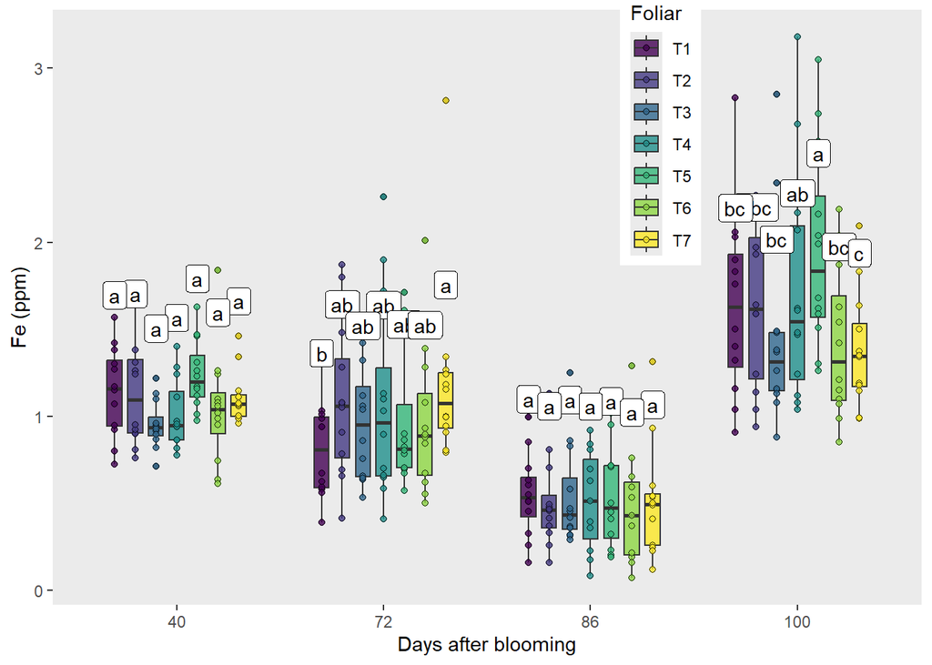

```r
fe <-
   best_models$iron %>%
   emmeans(~  foliar_trt | time) %>% # compares foliar_trt at each time point
   cld(alpha = 0.05, reversed = TRUE, adjust = "none", Letters=letters) %>%
   as.data.frame() %>%
   mutate(letter = trimws(.group))

ggplot(mapping = aes(fill = time)) +
   #raw data and boxplots
   geom_boxplot(data = sap_all_samples,
                aes(x = time, y = iron, fill = foliar_trt),
                width = 0.5,
                alpha = 0.8,
                position = position_dodge(width = 0.7)) +
   geom_point(data = sap_all_samples,
               aes(x = time, y = iron, fill = foliar_trt, group = foliar_trt),
               shape = 21,
               #size =3,
              position = position_dodge(width = 0.7),
               alpha = 0.8) +
   #adding letters
   geom_label(data = fe,
              aes(x = time, y = emmean, label = letter, group = foliar_trt),
              fill = "white",
              position = position_dodge(width = 0.7),
               vjust = -3) +
   labs(x = "Days after blooming",
        y = "Fe (ppm)",
        fill = "Foliar") +
   scale_fill_viridis_d() +
   #facet_grid(.~irr_system) +
   theme(panel.grid.major = element_blank(),
         panel.grid.minor = element_blank(),
         legend.position = c(0.7,0.8))
```

Potassium/Calcium ratio

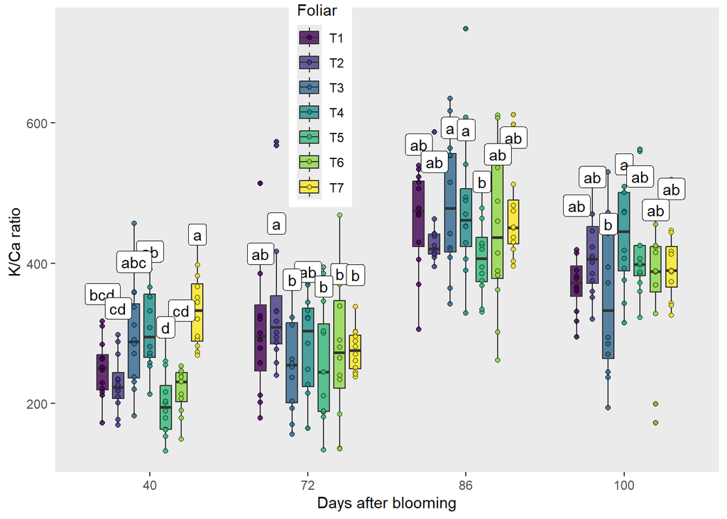

```r
kca <-
   best_models$kca_ratio %>%
   emmeans(~  foliar_trt | time) %>% # compares foliar_trt at each time point
   cld(alpha = 0.05, reversed = TRUE, adjust = "none", Letters=letters) %>%
   as.data.frame() %>%
   mutate(letter = trimws(.group))

ggplot(mapping = aes(fill = time)) +
   #raw data and boxplots
   geom_boxplot(data = sap_all_samples,
                aes(x = time, y = kca_ratio, fill = foliar_trt),
                width = 0.5,
                alpha = 0.8,
                position = position_dodge(width = 0.7)) +
   geom_point(data = sap_all_samples,
               aes(x = time, y = kca_ratio, fill = foliar_trt, group = foliar_trt),
               shape = 21,
               #size =3,
              position = position_dodge(width = 0.7),
               alpha = 0.8) +
   #adding letters
   geom_label(data = kca,
              aes(x = time, y = emmean, label = letter, group = foliar_trt),
              fill = "white",
              position = position_dodge(width = 0.7),
               vjust = -3) +
   labs(x = "Days after blooming",
        y = "K/Ca ratio ",
        fill = "Foliar") +
   scale_fill_viridis_d() +
   #facet_grid(.~irr_system) +
   theme(panel.grid.major = element_blank(),
         panel.grid.minor = element_blank(),
         legend.position = c(0.4,0.8))
```

Nitrogen

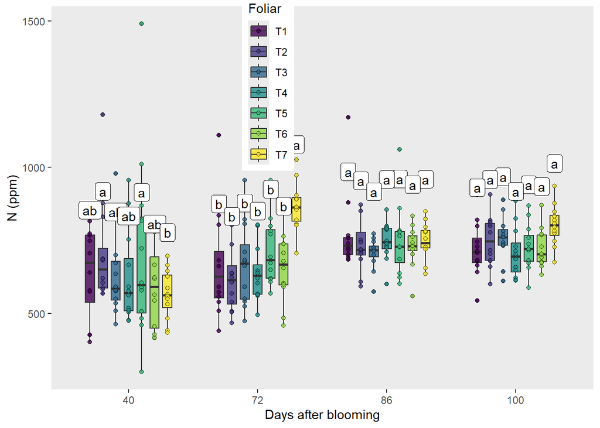

```r
n <-
   best_models$nitrogen %>%
   emmeans(~  foliar_trt | time) %>% # compares foliar_trt at each time point
   cld(alpha = 0.05, reversed = TRUE, adjust = "none", Letters=letters) %>%
   as.data.frame() %>%
   mutate(letter = trimws(.group))

ggplot(mapping = aes(fill = time)) +
   #raw data and boxplots
   geom_boxplot(data = sap_all_samples,
                aes(x = time, y = nitrogen, fill = foliar_trt),
                width = 0.5,
                alpha = 0.8,
                position = position_dodge(width = 0.7)) +
   geom_point(data = sap_all_samples,
               aes(x = time, y = nitrogen, fill = foliar_trt, group = foliar_trt),
               shape = 21,
               #size =3,
              position = position_dodge(width = 0.7),
               alpha = 0.8) +
   #adding letters
   geom_label(data = n,
              aes(x = time, y = emmean, label = letter, group = foliar_trt),
              fill = "white",
              position = position_dodge(width = 0.7),
               vjust = -3) +
   labs(x = "Days after blooming",
        y = "N (ppm)",
        fill = "Foliar") +
   scale_fill_viridis_d() +
   #facet_grid(.~irr_system) +
   theme(panel.grid.major = element_blank(),
         panel.grid.minor = element_blank(),
         legend.position = c(0.4,0.8))
```

pH

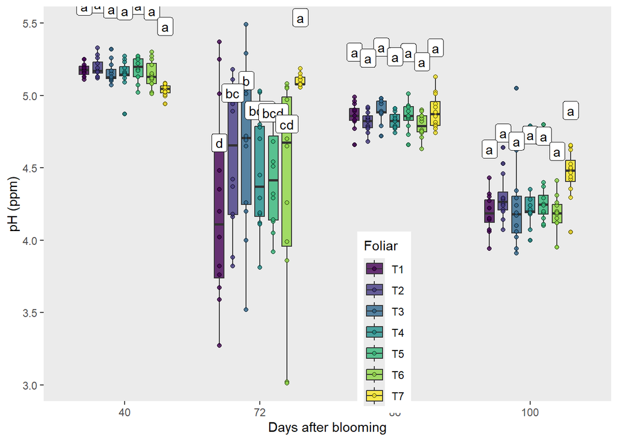

```r
ph <-
   best_models$ph %>%
   emmeans(~  foliar_trt | time) %>% # compares foliar_trt at each time point
   cld(alpha = 0.05, reversed = TRUE, adjust = "none", Letters=letters) %>%
   as.data.frame() %>%
   mutate(letter = trimws(.group))

ggplot(mapping = aes(fill = time)) +
   #raw data and boxplots
   geom_boxplot(data = sap_all_samples,
                aes(x = time, y = ph, fill = foliar_trt),
                width = 0.5,
                alpha = 0.8,
                position = position_dodge(width = 0.7)) +
   geom_point(data = sap_all_samples,
               aes(x = time, y = ph, fill = foliar_trt, group = foliar_trt),
               shape = 21,
               #size =3,
              position = position_dodge(width = 0.7),
               alpha = 0.8) +
   #adding letters
   geom_label(data = ph,
              aes(x = time, y = emmean, label = letter, group = foliar_trt),
              fill = "white",
              position = position_dodge(width = 0.7),
               vjust = -3) +
   labs(x = "Days after blooming",
        y = "pH (ppm)",
        fill = "Foliar") +
   scale_fill_viridis_d() +
   #facet_grid(.~irr_system) +
   theme(panel.grid.major = element_blank(),
         panel.grid.minor = element_blank(),
         legend.position = c(0.6,0.2))
```

Phosphorus

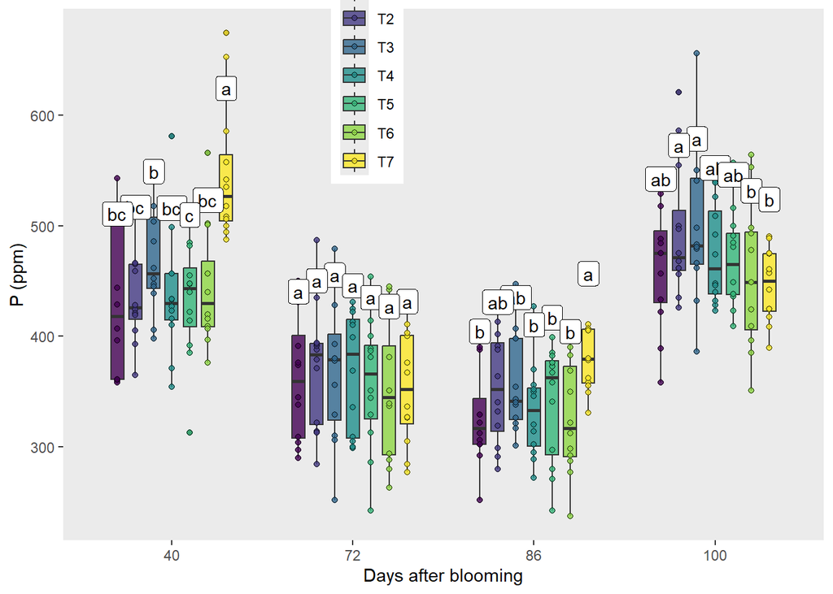

```r
p <-
   best_models$phosphorus %>%
   emmeans(~  foliar_trt | time) %>% # compares foliar_trt at each time point
   cld(alpha = 0.05, reversed = TRUE, adjust = "none", Letters=letters) %>%
   as.data.frame() %>%
   mutate(letter = trimws(.group))

ggplot(mapping = aes(fill = time)) +
   #raw data and boxplots
   geom_boxplot(data = sap_all_samples,
                aes(x = time, y = phosphorus, fill = foliar_trt),
                width = 0.5,
                alpha = 0.8,
                position = position_dodge(width = 0.7)) +
   geom_point(data = sap_all_samples,
               aes(x = time, y = phosphorus, fill = foliar_trt, group = foliar_trt),
               shape = 21,
               #size =3,
              position = position_dodge(width = 0.7),
               alpha = 0.8) +
   #adding letters
   geom_label(data = p,
              aes(x = time, y = emmean, label = letter, group = foliar_trt),
              fill = "white",
              position = position_dodge(width = 0.7),
               vjust = -3) +
   labs(x = "Days after blooming",
        y = "P (ppm)",
        fill = "Foliar") +
   scale_fill_viridis_d() +
   #facet_grid(.~irr_system) +
   theme(panel.grid.major = element_blank(),
         panel.grid.minor = element_blank(),
         legend.position = c(0.4,0.9))
```

Potassium

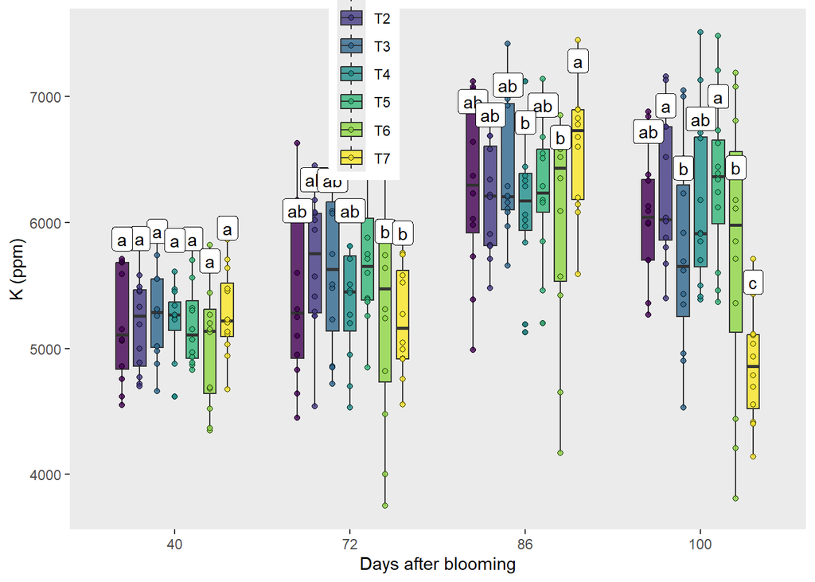

```r
k <-
   best_models$potassium %>%
   emmeans(~  foliar_trt | time) %>% # compares foliar_trt at each time point
   cld(alpha = 0.05, reversed = TRUE, adjust = "none", Letters=letters) %>%
   as.data.frame() %>%
   mutate(letter = trimws(.group))

ggplot(mapping = aes(fill = time)) +
   #raw data and boxplots
   geom_boxplot(data = sap_all_samples,
                aes(x = time, y = potassium, fill = foliar_trt),
                width = 0.5,
                alpha = 0.8,
                position = position_dodge(width = 0.7)) +
   geom_point(data = sap_all_samples,
               aes(x = time, y = potassium, fill = foliar_trt, group = foliar_trt),
               shape = 21,
               #size =3,
              position = position_dodge(width = 0.7),
               alpha = 0.8) +
   #adding letters
   geom_label(data = k,
              aes(x = time, y = emmean, label = letter, group = foliar_trt),
              fill = "white",
              position = position_dodge(width = 0.7),
               vjust = -3) +
   labs(x = "Days after blooming",
        y = "K (ppm)",
        fill = "Foliar") +
   scale_fill_viridis_d() +
   #facet_grid(.~irr_system) +
   theme(panel.grid.major = element_blank(),
         panel.grid.minor = element_blank(),
         legend.position = c(0.4,0.9))
```

Silica

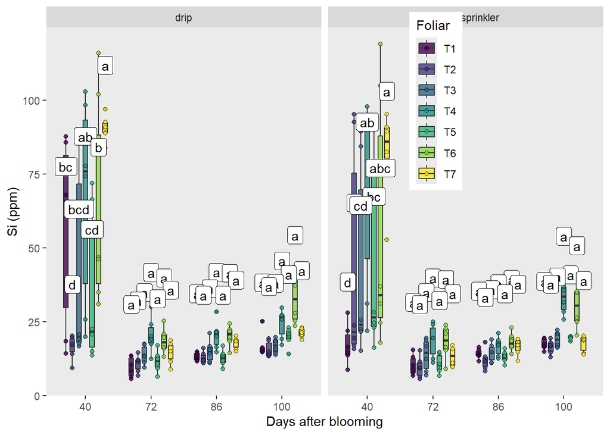

```r
#estimated marginal means (a.k.a. least-squares means)
si <-
   best_models$silica %>%
   emmeans(~  foliar_trt|irr_system| time) %>% #compares foliar_trt within each irrigation
   cld(alpha = 0.05, reversed = TRUE, adjust = "none", Letters=letters) %>%
   as.data.frame() %>%
   mutate(letter = trimws(.group))

ggplot(mapping = aes(fill = time)) +
   #raw data and boxplots
   geom_boxplot(data = sap_all_samples,
                aes(x = time, y = silica, fill = foliar_trt),
                width = 0.5,
                alpha = 0.8,
                position = position_dodge(width = 0.7)) +
   geom_point(data = sap_all_samples,
               aes(x = time, y = silica, fill = foliar_trt, group = foliar_trt),
               shape = 21,
               #size =3,
              position = position_dodge(width = 0.7),
               alpha = 0.8) +
   #adding letters
   geom_label(data = si,
              aes(x = time, y = emmean, label = letter, group = foliar_trt),
              fill = "white",
              position = position_dodge(width = 0.7),
               vjust = -3) +
   labs(x = "Days after blooming",
        y = "Si (ppm)",
        fill = "Foliar") +
   scale_fill_viridis_d() +
   facet_grid(.~irr_system) +
   theme(panel.grid.major = element_blank(),
         panel.grid.minor = element_blank(),
         legend.position = c(0.7,0.8))
```

Sulfur

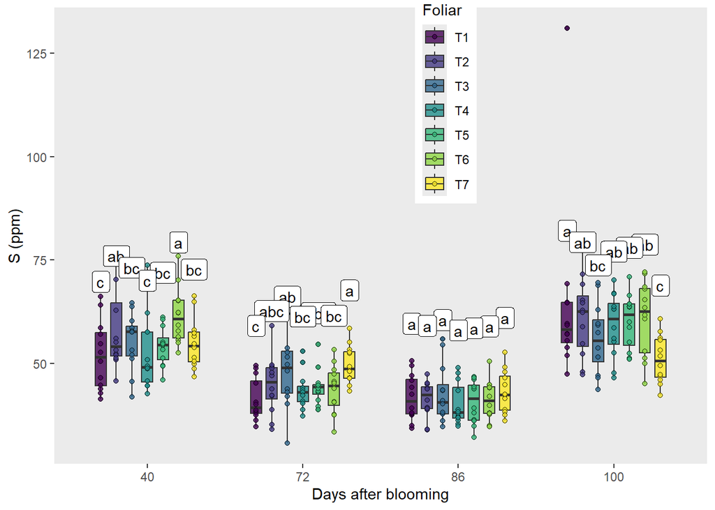

```r
s <-
   best_models$sulfur %>%
   emmeans(~  foliar_trt | time) %>% #
   cld(alpha = 0.05, reversed = TRUE, adjust = "none", Letters=letters) %>%
   as.data.frame() %>%
   mutate(letter = trimws(.group))

ggplot(mapping = aes(fill = time)) +
   #raw data and boxplots
   geom_boxplot(data = sap_all_samples,
                aes(x = time, y = sulfur, fill = foliar_trt),
                width = 0.5,
                alpha = 0.8,
                position = position_dodge(width = 0.7)) +
   geom_point(data = sap_all_samples,
               aes(x = time, y = sulfur, fill = foliar_trt, group = foliar_trt),
               shape = 21,
               #size =3,
              position = position_dodge(width = 0.7),
               alpha = 0.8) +
   #adding letters
   geom_label(data = s,
              aes(x = time, y = emmean, label = letter, group = foliar_trt),
              fill = "white",
              position = position_dodge(width = 0.7),
               vjust = -3) +
   labs(x = "Days after blooming",
        y = "S (ppm)",
        fill = "Foliar") +
   scale_fill_viridis_d() +
   #facet_grid(.~irr_system) +
   theme(panel.grid.major = element_blank(),
         panel.grid.minor = element_blank(),
         legend.position = c(0.6,0.8))
```

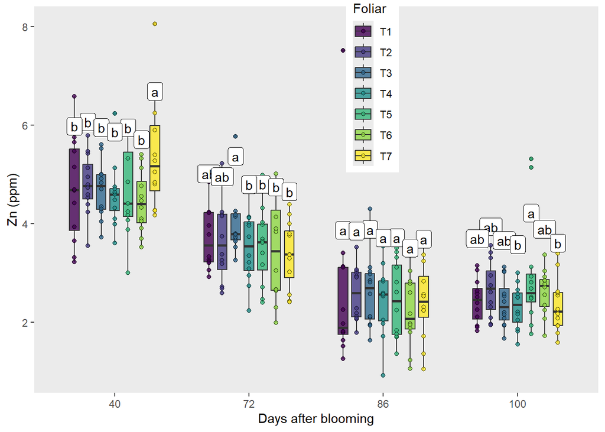

```r
zn <-
   best_models$zinc %>%
   emmeans(~  foliar_trt | time) %>% #
   cld(alpha = 0.05, reversed = TRUE, adjust = "none", Letters=letters) %>%
   as.data.frame() %>%
   mutate(letter = trimws(.group))

ggplot(mapping = aes(fill = time)) +
   #raw data and boxplots
   geom_boxplot(data = sap_all_samples,
                aes(x = time, y = zinc, fill = foliar_trt),
                width = 0.5,
                alpha = 0.8,
                position = position_dodge(width = 0.7)) +
   geom_point(data = sap_all_samples,
               aes(x = time, y = zinc, fill = foliar_trt, group = foliar_trt),
               shape = 21,
               #size =3,
              position = position_dodge(width = 0.7),
               alpha = 0.8) +
   #adding letters
   geom_label(data = zn,
              aes(x = time, y = emmean, label = letter, group = foliar_trt),
              fill = "white",
              position = position_dodge(width = 0.7),
               vjust = -3) +
   labs(x = "Days after blooming",
        y = "Zn (ppm)",
        fill = "Foliar") +
   scale_fill_viridis_d() +
   #facet_grid(.~irr_system) +
   theme(panel.grid.major = element_blank(),
         panel.grid.minor = element_blank(),
         legend.position = c(0.6,0.8))
```

In general, we would expect the T7 to have higher levels of macronutrients since it has received soil-based fertilization twice a year, pre- and post-harvest.

# 6 Team work in GitHub

Whether you are working with your future-self or as duos, make sure to stage, commit, and push after finishing each of the sub-sections above. When committing, write commit messages that are short and descriptive (e.g., finished wrangling).

If you are working in duos, make sure to split the workload. I will check your collaborative work through the commit history, and if one student has contributed significantly more than the other, than that will impact grades.

**Tip 1**: to avoid merge conflicts, make sure to **pull** first, and then start working locally. That will ensure that any changes made by your partner will be “downloaded” before you make changes to the files locally.

**Tip 2**: make use of the Issues on this repository to set up to-do lists and assign tasks to different people. You can also use each issue/task to discuss how things should be run and get to an agreement.

# 7 Submitting your work

Once you have developed all the code and answers, make sure to Render this quarto file.

**Notes on rendering**:

- Make sure to render your work and inspect how the final html look like.
- If it does not look professional for whatever reason, then fix the issue, re-render it, recheck.
- Only send me your work once your html file looks professional.
- Some potential issues you may encounter and how to fix them:
  - Some times your code may be creating a table output that is waaay to long and cumbersome to scroll through when rendered. If this is the case, make it more professional looking by using the `head()` function to only print the first handful of rows (instead of thousands of rows).
  - **DO NOT** delete the file’s heading levels (# and ##). They set up the proper heading 1 and 2 levels, and I use them to guide my grading.
  - If a given chunk is also outputting warnings or messages, inhibit this behavior by changing the chunk options `message` and `warning` to `FALSE`.
  - If, after rendered, 2 lines of text are connected and you wish to “break line” between them, add 2 extra spaces after the first one.

After rendering, an .html file will be created on your `code` folder.

Rename this file to `LASTNAME1-LASTNAME2_finalproject.html`.  
For ex., `Bastos-Mendes_finalproject.html`.

Submit the html file on eLC by **April 30th** 11:59 pm.